# Estrategias Focalizadas para Sellers en Mercado Libre

#### 1. Problema a Resolver

- El equipo comercial de Mercado Libre necesita identificar y clasificar a los sellers con buen perfil y relevancia para el negocio, pero actualmente no cuentan con una clasificación que permita realizar estrategias focalizadas.

#### Objetivo: Desarrollar un modelo de clasificación para segmentar a los sellers de Mercado Libre, para poder tener estrategias focalizadas de acuerdo al perfil de cada seller

#### 2. Información Utilizada y Hipótesis

- **Datos Utilizados:**
  - Datos de ventas, precios, descuentos, adopción de MercadoPago, envíos gratuitos, y categorías de productos.
  - Información de sellers incluyendo si son tienda oficial, cantidad de ítems y volumen de ventas potencial.
- **Hipótesis:**
  - Los sellers pueden ser segmentados en grupos distintos con características únicas.
  - La segmentación permitirá diseñar estrategias comerciales específicas para mejorar el rendimiento y relevancia de los sellers.
  - La diversidad de items y precios, así como el dar envío gratis, permitir pago en plazos y otros factores nos pueden ayudar a diferenciar a sellers

#### 3. Insights Relevantes del Análisis Exploratorio

- **Descuentos Estratégicos:**
  - Variabilidad significativa en descuentos entre categorías y sitios.
- **Volumen de Ventas:**
  - Altos volúmenes en categorías como Celulares y Telefonía.
- **Envíos Gratuitos:**
  - Diferencias en tasas de envíos gratuitos entre países.
- **Diversidad de Productos:**
  - Variabilidad en el número de ítems por vendedor y categoría.
- **Categorías y Clusters:**
  - Diferentes clusters dominan en distintas categorías, como Celulares y Videojuegos.

#### 4. Contexto de la Solución y Metodologías Aplicadas

- **Solución Escogida:**
  - Desarrollo de un modelo de clustering para segmentar a los sellers.
- **Metodologías Aplicadas:**
  - Análisis exploratorio de datos.
  - Algoritmo de K-Means para clustering.
  - Evaluación mediante el método del codo para determinar el número óptimo de clusters (6)
- **Métricas de Evaluación:**
  - Validación interna mediante análisis de distribución y características de cada cluster.

#### 5. Solución Final y Comportamiento

- **Solución Final:**
  - Segmentación de sellers en seis clusters: Aspirantes de Nicho, Iniciadores de Bajo Costo, Premium Movers, Diversificados Establecidos, Exploradores Moderados, y Gigantes Oficiales.
- **Comportamiento de la Solución:**
  - Cada cluster muestra características únicas en términos de precios, volumen de ventas, descuentos, y diversidad de productos.
- **Beneficios:**
  - Permite diseñar estrategias comerciales específicas para cada grupo.
  - Mejora la eficiencia y efectividad de las acciones de marketing y ventas.

#### 6. Conclusión y Próximos Pasos

- **Conclusión:**
  - La segmentación permite al equipo comercial identificar rápidamente a los sellers con mayor potencial y adaptar sus estrategias para maximizar el impacto.
- **Próximos Pasos:**
  - Mejorar clusterización con data de ordenes, conversión, búsquedas, opiniones de usuarios y competencia
  - Validar clusters con insights cualitativos y feedback de usuarios.
  - Realizar un análisis profundo por categoría y subcategoría.
  - Implementar experimentación con grupos controlados y evaluar los resultados antes de un despliegue completo.

```python
#############
### LIBRERIAS
#############

import pandas as pd
import matplotlib.pyplot as plt
import numpy as np
import seaborn as sns
import requests
import time
import os
import json

from sklearn.preprocessing import StandardScaler
from sklearn.cluster import KMeans


pd.options.display.float_format = '{:,.2f}'.format
```

```python
import pandoc
```

```python
#############
### FUNCIONES
#############

# Función para obtener todas las categorías de un sitio
def fetch_categories_multinational(site_ids):
    all_categories = []
    for site_id in site_ids:
        url = f'https://api.mercadolibre.com/sites/{site_id}/categories'
        response = requests.get(url)
        data = response.json()
        for category in data:
            category['site_id'] = site_id  # Agregar el país a cada categoría
        all_categories.extend(data)
    categories_df = pd.DataFrame(all_categories)
    return categories_df

def get_categories_and_subcategories(site_ids, categories_of_interest):
    categories_data = []
    for site_id in site_ids:
        for category_id in categories_of_interest:
            url = f'https://api.mercadolibre.com/categories/{category_id}'
            response = requests.get(url)
            data = response.json()
            category_name = data.get('name')
            children_categories = data.get('children_categories', [])
            for subcat in children_categories:
                subcat_id = subcat['id']
                subcat_name = subcat['name']
                categories_data.append({
                    'site_id': site_id,
                    'category_id': category_id,
                    'category_name': category_name,
                    'subcat_id': subcat_id,
                    'subcat_name': subcat_name
                })
    return pd.DataFrame(categories_data)

# Función para extraer items de un sitio y guardarlos en csv
def fetch_items_for_single_site(site_id, categories, limit=50, items_per_category=5000):
    all_items_data = []
    for category_id in categories:
        category_name = categories_df[categories_df['id'] == category_id]['name'].values[0]
        for offset in range(0, items_per_category, limit):
            url = f'https://api.mercadolibre.com/sites/{site_id}/search?category={category_id}&offset={offset}'
            response = requests.get(url)
            data = response.json()
            if 'results' in data:
                for item in data['results']:
                    item['category_name'] = category_name
                    item['country'] = site_id  # Add the country
                    all_items_data.append(item)
            else:
                break

    items_df = pd.DataFrame(all_items_data)
    items_df.to_csv(f'items_data_{site_id}.csv', index=False)
    return items_df

# Función para extraer items para los sitios seleccionados y juntarlos en 1 solo df
def fetch_items_for_all_sites(site_ids, categories_by_country, limit=50, items_per_category=5000):
    all_items_data = []
    for site_id, categories in categories_by_country.items():
        print(f"Fetching data for site: {site_id}")
        items_df = fetch_items_for_single_site(site_id, categories, limit, items_per_category)
        all_items_data.append(items_df)

    combined_items_df = pd.concat(all_items_data, ignore_index=True)
    combined_items_df.to_csv('combined_items_data.csv', index=False)
    return combined_items_df

# Función para obtener tipo de cambio
def get_exchange_rate(from_currency, to_currency="USD"):
    url = f"https://api.mercadolibre.com/currency_conversions/search?from={from_currency}&to={to_currency}"
    response = requests.get(url)
    data = response.json()
    return data['ratio']

# Función para convertir precios a USD
def convert_to_usd(price, currency_id):
    if pd.isna(price):  # Si el precio es NaN, devolver NaN
        return price
    if currency_id == "ARS":
        return price * ars_to_usd
    elif currency_id == "MXN":
        return price * mxn_to_usd
    elif currency_id == "COP":
        return price * cop_to_usd
    elif currency_id == "CLP":
        return price * clp_to_usd
    else:
        return price

# Función útil para remover outliers en análisis exploratorio de datos
def remove_outliers(df, column):
    Q1 = df[column].quantile(0.25)
    Q3 = df[column].quantile(0.75)
    IQR = Q3 - Q1
    lower_bound = Q1 - 1.5 * IQR
    upper_bound = Q3 + 1.5 * IQR
    return df[(df[column] >= lower_bound) & (df[column] <= upper_bound)]
```

# 1. Extracción de información a través de la API de Mercado Libre

- Se obtuvo información de categorías, subcategorías y de items

Intenté obtener datos de ordenes, opiniones y búsquedas de los usuarios, pero se requería una API. Investigando ví que tenía que crear una aplicación para obtener el API Key. No tuve éxito en ello y por cuestiones de tiempo opté por trabajar con la data que podía obtener.

El proceso fue:

1. Extracción de categorías para Argentina, Colombia, México y Chile
2. Me quedé con las categorías relevantes de consumer electronics
3. Extracción de ítems por site por categoría

```python
#############
### DESCARGA DE DATOS
#############
# Categorías
site_ids = ['MLA', 'MCO', 'MLM', 'MLC']

categories_df = fetch_categories_multinational(site_ids)
categories_list = categories_df[['site_id', 'id', 'name']].to_dict(orient='records')
for category in categories_list:
    print(category)
```

```
{'site_id': 'MLA', 'id': 'MLA5725', 'name': 'Accesorios para Vehículos'}
{'site_id': 'MLA', 'id': 'MLA1512', 'name': 'Agro'}
{'site_id': 'MLA', 'id': 'MLA1403', 'name': 'Alimentos y Bebidas'}
{'site_id': 'MLA', 'id': 'MLA1071', 'name': 'Animales y Mascotas'}
{'site_id': 'MLA', 'id': 'MLA1367', 'name': 'Antigüedades y Colecciones'}
{'site_id': 'MLA', 'id': 'MLA1368', 'name': 'Arte, Librería y Mercería'}
{'site_id': 'MLA', 'id': 'MLA1743', 'name': 'Autos, Motos y Otros'}
{'site_id': 'MLA', 'id': 'MLA1384', 'name': 'Bebés'}
{'site_id': 'MLA', 'id': 'MLA1246', 'name': 'Belleza y Cuidado Personal'}
{'site_id': 'MLA', 'id': 'MLA1039', 'name': 'Cámaras y Accesorios'}
{'site_id': 'MLA', 'id': 'MLA1051', 'name': 'Celulares y Teléfonos'}
{'site_id': 'MLA', 'id': 'MLA1648', 'name': 'Computación'}
{'site_id': 'MLA', 'id': 'MLA1144', 'name': 'Consolas y Videojuegos'}
{'site_id': 'MLA', 'id': 'MLA1500', 'name': 'Construcción'}
{'site_id': 'MLA', 'id': 'MLA1276', 'name': 'Deportes y Fitness'}
{'site_id': 'MLA', 'id': 'MLA5726', 'name': 'Electrodomésticos y Aires Ac.'}
{'site_id': 'MLA', 'id': 'MLA1000', 'name': 'Electrónica, Audio y Video'}
{'site_id': 'MLA', 'id': 'MLA2547', 'name': 'Entradas para Eventos'}
{'site_id': 'MLA', 'id': 'MLA407134', 'name': 'Herramientas'}
{'site_id': 'MLA', 'id': 'MLA1574', 'name': 'Hogar, Muebles y Jardín'}
{'site_id': 'MLA', 'id': 'MLA1499', 'name': 'Industrias y Oficinas'}
{'site_id': 'MLA', 'id': 'MLA1459', 'name': 'Inmuebles'}
{'site_id': 'MLA', 'id': 'MLA1182', 'name': 'Instrumentos Musicales'}
{'site_id': 'MLA', 'id': 'MLA3937', 'name': 'Joyas y Relojes'}
{'site_id': 'MLA', 'id': 'MLA1132', 'name': 'Juegos y Juguetes'}
{'site_id': 'MLA', 'id': 'MLA3025', 'name': 'Libros, Revistas y Comics'}
{'site_id': 'MLA', 'id': 'MLA1168', 'name': 'Música, Películas y Series'}
{'site_id': 'MLA', 'id': 'MLA1430', 'name': 'Ropa y Accesorios'}
{'site_id': 'MLA', 'id': 'MLA409431', 'name': 'Salud y Equipamiento Médico'}
{'site_id': 'MLA', 'id': 'MLA1540', 'name': 'Servicios'}
{'site_id': 'MLA', 'id': 'MLA9304', 'name': 'Souvenirs, Cotillón y Fiestas'}
{'site_id': 'MLA', 'id': 'MLA1953', 'name': 'Otras categorías'}
{'site_id': 'MCO', 'id': 'MCO1747', 'name': 'Accesorios para Vehículos'}
{'site_id': 'MCO', 'id': 'MCO441917', 'name': 'Agro'}
{'site_id': 'MCO', 'id': 'MCO1403', 'name': 'Alimentos y Bebidas'}
{'site_id': 'MCO', 'id': 'MCO1071', 'name': 'Animales y Mascotas'}
{'site_id': 'MCO', 'id': 'MCO1367', 'name': 'Antigüedades y Colecciones'}
{'site_id': 'MCO', 'id': 'MCO1368', 'name': 'Arte, Papelería y Mercería'}
{'site_id': 'MCO', 'id': 'MCO1384', 'name': 'Bebés'}
{'site_id': 'MCO', 'id': 'MCO1246', 'name': 'Belleza y Cuidado Personal'}
```

[output cut: 72 more lines]

```
{'site_id': 'MLC', 'id': 'MLC110931', 'name': 'Entradas para Eventos'}
{'site_id': 'MLC', 'id': 'MLC178483', 'name': 'Herramientas'}
{'site_id': 'MLC', 'id': 'MLC1574', 'name': 'Hogar y Muebles'}
{'site_id': 'MLC', 'id': 'MLC1499', 'name': 'Industrias y Oficinas'}
{'site_id': 'MLC', 'id': 'MLC1459', 'name': 'Inmuebles'}
{'site_id': 'MLC', 'id': 'MLC1182', 'name': 'Instrumentos Musicales'}
{'site_id': 'MLC', 'id': 'MLC1132', 'name': 'Juegos y Juguetes'}
{'site_id': 'MLC', 'id': 'MLC3025', 'name': 'Libros, Revistas y Comics'}
{'site_id': 'MLC', 'id': 'MLC1168', 'name': 'Música y Películas'}
{'site_id': 'MLC', 'id': 'MLC3937', 'name': 'Relojes y Joyas'}
{'site_id': 'MLC', 'id': 'MLC409431', 'name': 'Salud y Equipamiento Médico'}
{'site_id': 'MLC', 'id': 'MLC1540', 'name': 'Servicios'}
{'site_id': 'MLC', 'id': 'MLC435280', 'name': 'Souvenirs, Cotillón y Fiestas'}
{'site_id': 'MLC', 'id': 'MLC1430', 'name': 'Vestuario y Calzado'}
{'site_id': 'MLC', 'id': 'MLC1953', 'name': 'Otras Categorías'}
```

```python
# Categories of interest for each country
categories_of_interest_mexico = ['MLM1000', 'MLM1051', 'MLM1144', 'MLM1648']
categories_of_interest_argentina = ['MLA1000', 'MLA1051', 'MLA1144', 'MLA1648']
categories_of_interest_colombia = ['MCO1000', 'MCO1051', 'MCO1144', 'MCO1648']
categories_of_interest_chile = ['MLC1000', 'MLC1051', 'MLC1144', 'MLC1648']

categories_by_country = {
    'MLM': categories_of_interest_mexico,
    'MLA': categories_of_interest_argentina,
    'MCO': categories_of_interest_colombia,
    'MLC': categories_of_interest_chile
}

categories_of_interest =['MLM1000', 'MLM1051', 'MLM1144', 'MLM1648',
                        'MLA1000', 'MLA1051', 'MLA1144', 'MLA1648',
                        'MCO1000', 'MCO1051', 'MCO1144', 'MCO1648',
                        'MLC1000', 'MLC1051', 'MLC1144', 'MLC1648']
```

```python
categories_df[categories_df['id'].isin (categories_of_interest)]
```

|  | id | name | site_id |
| --- | --- | --- | --- |
| 10 | MLA1051 | Celulares y Teléfonos | MLA |
| 11 | MLA1648 | Computación | MLA |
| 12 | MLA1144 | Consolas y Videojuegos | MLA |
| 16 | MLA1000 | Electrónica, Audio y Video | MLA |
| 43 | MCO1051 | Celulares y Teléfonos | MCO |
| 44 | MCO1648 | Computación | MCO |
| 45 | MCO1144 | Consolas y Videojuegos | MCO |
| 49 | MCO1000 | Electrónica, Audio y Video | MCO |
| 74 | MLM1051 | Celulares y Telefonía | MLM |
| 75 | MLM1648 | Computación | MLM |
| 76 | MLM1144 | Consolas y Videojuegos | MLM |
| 80 | MLM1000 | Electrónica, Audio y Video | MLM |
| 105 | MLC1051 | Celulares y Telefonía | MLC |
| 106 | MLC1648 | Computación | MLC |
| 107 | MLC1144 | Consolas y Videojuegos | MLC |
| 111 | MLC1000 | Electrónica, Audio y Video | MLC |

```python
# Categorías y sub-categorías
categories_subcategories_df = get_categories_and_subcategories(site_ids, categories_of_interest)
```

```python
categories_subcategories_df = categories_subcategories_df[['subcat_id','subcat_name']]
```

```python
categories_subcategories_df.head(5)
```

|  | subcat_id | subcat_name |
| --- | --- | --- |
| 0 | MLA3690 | Accesorios para Audio y Video |
| 1 | MLA431414 | Accesorios para TV |
| 2 | MLA409810 | Audio |
| 3 | MLA5054 | Cables |
| 4 | MLA11830 | Componentes Electrónicos |

```python
# Descarga de items para cada site_id y para las categorías de interés
combined_items_df = fetch_items_for_all_sites(site_ids, categories_by_country)
```

```
Fetching data for site: MLM
Fetching data for site: MLA
Fetching data for site: MCO
Fetching data for site: MLC
```

```python
items_df = combined_items_df
print(items_df.info())
```

```
<class 'pandas.core.frame.DataFrame'>
RangeIndex: 16703 entries, 0 to 16702
Data columns (total 37 columns):
 #   Column                Non-Null Count  Dtype
---  ------                --------------  -----
 0   id                    16703 non-null  object
 1   title                 16703 non-null  object
 2   condition             16703 non-null  object
 3   thumbnail_id          16703 non-null  object
 4   catalog_product_id    14011 non-null  object
 5   listing_type_id       16703 non-null  object
 6   permalink             16703 non-null  object
 7   buying_mode           16703 non-null  object
 8   site_id               16703 non-null  object
 9   category_id           16703 non-null  object
```

[output cut: 30 more lines]

```python
items_df.head(5)
```

|  | id | title | condition | thumbnail_id | catalog_product_id | listing_type_id | permalink | buying_mode | site_id | category_id | ... | catalog_listing | discounts | promotions | inventory_id | category_name | country | official_store_name | differential_pricing | variation_filters | variations_data |
| --- | --- | --- | --- | --- | --- | --- | --- | --- | --- | --- | --- | --- | --- | --- | --- | --- | --- | --- | --- | --- | --- |
| 0 | MLM3166352008 | Bocina Jbl Go 3 Jblgo3 Portátil Con Bluetooth ... | new | 624129-MLU72571585392_112023 | MLM16247314 | gold_special | https://www.mercadolibre.com.mx/bocina-jbl-go-... | buy_it_now | MLM | MLM59800 | ... | True | None | [] | RTNR70871 | Electrónica, Audio y Video | MLM | NaN | NaN | NaN | NaN |
| 1 | MLM2080126365 | Audífono In-ear Inalámbrico Keluona M90 Pro M9... | new | 909186-MLA71521920131_092023 | MLM26810871 | gold_special | https://www.mercadolibre.com.mx/audifono-in-ea... | buy_it_now | MLM | MLM7533 | ... | True | None | [] | IIOF61175 | Electrónica, Audio y Video | MLM | NaN | NaN | NaN | NaN |
| 2 | MLM2606504262 | Bocina Bluetooth Speaker 1hora Boc241 Para Pc ... | new | 797961-MLA74807969159_022024 | MLM22801217 | gold_special | https://www.mercadolibre.com.mx/bocina-bluetoo... | buy_it_now | MLM | MLM2868 | ... | True | None | [] | None | Electrónica, Audio y Video | MLM | NaN | NaN | NaN | NaN |
| 3 | MLM1799809870 | Bocina Portátil Jbl Flip 6 Bluetooth Aprueba D... | new | 913774-MLU76917425907_062024 | MLM18930466 | gold_special | https://www.mercadolibre.com.mx/bocina-portati... | buy_it_now | MLM | MLM59800 | ... | True | None | [] | VSHJ02537 | Electrónica, Audio y Video | MLM | Selectshop MX | NaN | NaN | NaN |
| 4 | MLM1978928449 | Drone Lyzrc L900 Pro L900 Pro Se L900 Se Con ... | new | 813204-MLA71822760790_092023 | MLM27215338 | gold_pro | https://www.mercadolibre.com.mx/drone-lyzrc-l9... | buy_it_now | MLM | MLM149102 | ... | True | None | [] | ZIXW64211 | Electrónica, Audio y Video | MLM | NaN | {'id': 35713377} | NaN | NaN |

5 rows × 37 columns

```python
# Obtenemos tipos de cambio para transformar todo a usd
ars_to_usd = get_exchange_rate("ARS", "USD")
mxn_to_usd = get_exchange_rate("MXN", "USD")
cop_to_usd = get_exchange_rate("COP", "USD")
clp_to_usd = get_exchange_rate("CLP", "USD")

print(f"ARS to USD: {ars_to_usd}")
print(f"MXN to USD: {mxn_to_usd}")
print(f"COP to USD: {cop_to_usd}")
print(f"CLP to USD: {clp_to_usd}")
```

```
ARS to USD: 0.00109409
MXN to USD: 0.05437827
COP to USD: 0.00024108
CLP to USD: 0.00105894
```

```python
# Convertimos precios a USD
items_df['price_usd'] = items_df.apply(lambda row: convert_to_usd(row['price'], row['currency_id']), axis=1)
items_df['original_price_usd'] = items_df.apply(lambda row: convert_to_usd(row['original_price'], row['currency_id']), axis=1)
```

- Celulares y Teléfonos
- Computación
- Consolas y Videojuegos
- Electrónica, Audio y Video

Para los siguientes países:

- México
- Colombia
- Argentina
- Chile

Importante: Esto es una muestra de ítems, por lo que asumiré que nos da una muestra representativa de los sellers de la plataforma

```python
#############
### LIMPIEZA DE DATOS
#############
# Convertimos JSON a Columnas
seller_df = pd.json_normalize(items_df['seller'])
shipping_df = pd.json_normalize(items_df['shipping'])
installments_df = pd.json_normalize(items_df['installments'])
```

[output not shown]

```python
# Unir los campos normalizados al DataFrame principal
items_df = items_df.drop(columns=['seller', 'shipping', 'installments']) \
                   .join(seller_df.add_prefix('seller_')) \
                   .join(shipping_df.add_prefix('shipping_')) \
                   .join(installments_df.add_prefix('installments_'))
```

```python
print(items_df.info())
```

```
<class 'pandas.core.frame.DataFrame'>
RangeIndex: 16703 entries, 0 to 16702
Data columns (total 50 columns):
 #   Column                    Non-Null Count  Dtype
---  ------                    --------------  -----
 0   id                        16703 non-null  object
 1   title                     16703 non-null  object
 2   condition                 16703 non-null  object
 3   thumbnail_id              16703 non-null  object
 4   catalog_product_id        14011 non-null  object
 5   listing_type_id           16703 non-null  object
 6   permalink                 16703 non-null  object
 7   buying_mode               16703 non-null  object
 8   site_id                   16703 non-null  object
 9   category_id               16703 non-null  object
```

[output cut: 43 more lines]

```python
# Me quedo con columnas que pueden ser relevantes para el análisis
relevant_columns = [
    'id', 'title', 'condition', 'thumbnail_id', 'catalog_product_id',
    'listing_type_id', 'permalink', 'buying_mode', 'site_id',
    'category_id', 'domain_id', 'thumbnail', 'currency_id', 'price',
    'original_price', 'sale_price', 'available_quantity', 'official_store_id',
    'official_store_name', 'use_thumbnail_id', 'accepts_mercadopago', 'stop_time',
    'seller_id', 'seller_nickname', 'attributes', 'installments_quantity',
    'installments_amount', 'installments_rate', 'winner_item_id',
    'catalog_listing', 'discounts', 'promotions', 'inventory_id',
    'differential_pricing', 'variation_filters', 'variations_data',
    'shipping_free_shipping', 'shipping_logistic_type', 'price_usd', 'original_price_usd','category_name'
]

# Filtro columnas relevantes
existing_columns = [col for col in relevant_columns if col in items_df.columns]
df = items_df[existing_columns]
```

```python
# Calcular el volumen de ventas potencial en USD
df.loc[:, 'sales_volume_usd'] = df['price_usd'] * df['available_quantity']

# Calcular el porcentaje de descuento en USD
df.loc[:, 'discount_percentage_usd'] = ((df['original_price_usd'] - df['price_usd']) / df['original_price_usd']) * 100

# Calcular la tasa de adopción de Mercadopago por ítem
df.loc[:, 'mercadopago_adoption'] = df['accepts_mercadopago'].astype(int)

# Calcular la proporción de envíos gratis por ítem
df.loc[:, 'free_shipping'] = df['shipping_free_shipping'].astype(int)
```

```python
df = df.merge(categories_subcategories_df, left_on='category_id', right_on='subcat_id', how='left')
```

```python
df.info()
```

```
<class 'pandas.core.frame.DataFrame'>
Int64Index: 31427 entries, 0 to 31426
Data columns (total 47 columns):
 #   Column                   Non-Null Count  Dtype
---  ------                   --------------  -----
 0   id                       31427 non-null  object
 1   title                    31427 non-null  object
 2   condition                31427 non-null  object
 3   thumbnail_id             31427 non-null  object
 4   catalog_product_id       26128 non-null  object
 5   listing_type_id          31427 non-null  object
 6   permalink                31427 non-null  object
 7   buying_mode              31427 non-null  object
 8   site_id                  31427 non-null  object
 9   category_id              31427 non-null  object
```

[output cut: 39 more lines]

Hasta aquí tenemos un dataframe a nivel item

# 2. Análisis Exploratorio

## 2.1 Análisis por categorías por país

Primero quiero entender a grandes razgos diferencías por país

```python
df['is_official_store'] = df['official_store_id'].notnull().astype(int)
```

```python
sales_volume_category_df = df.groupby(['site_id', 'category_name'])['sales_volume_usd'].sum().reset_index()
sales_volume_category_df.columns = ['site_id', 'category_name', 'total_sales_volume_usd']

# Calcular el descuento promedio por categoría y país en USD
average_discount_category_df = df.groupby(['site_id', 'category_name'])['discount_percentage_usd'].mean().reset_index()
average_discount_category_df.columns = ['site_id', 'category_name', 'average_discount_percentage_usd']

# Calcular la tasa de adopción de Mercadopago por categoría y país
mercadopago_adoption_category_df = df.groupby(['site_id', 'category_name'])['mercadopago_adoption'].mean().reset_index()
mercadopago_adoption_category_df.columns = ['site_id', 'category_name', 'mercadopago_adoption_rate']

# Calcular la proporción de envíos gratis por categoría y país
free_shipping_category_df = df.groupby(['site_id', 'category_name'])['free_shipping'].mean().reset_index()
free_shipping_category_df.columns = ['site_id', 'category_name', 'free_shipping_rate']

# Calcular el número de ítems por categoría y país
items_count_category_df = df.groupby(['site_id', 'category_name'])['id'].count().reset_index()
items_count_category_df.columns = ['site_id', 'category_name', 'items_count']

# Combinar todas las métricas en un solo DataFrame
category_summary_df = sales_volume_category_df.merge(average_discount_category_df, on=['site_id', 'category_name'])
category_summary_df = category_summary_df.merge(mercadopago_adoption_category_df, on=['site_id', 'category_name'])
category_summary_df = category_summary_df.merge(free_shipping_category_df, on=['site_id', 'category_name'])
category_summary_df = category_summary_df.merge(items_count_category_df, on=['site_id', 'category_name'])

# Seleccionar las columnas y renombrar
category_summary_df = category_summary_df[['site_id', 'category_name', 'total_sales_volume_usd', 'average_discount_percentage_usd', 'mercadopago_adoption_rate', 'free_shipping_rate', 'items_count']]

# Calcular el conteo de sellers por categoría y país
sellers_count_category_df = df.groupby(['site_id', 'category_name'])['seller_id'].nunique().reset_index()
sellers_count_category_df.columns = ['site_id', 'category_name', 'sellers_count']

# Calcular el promedio de items por seller por categoría y país
avg_items_per_seller_category_df = df.groupby(['site_id', 'category_name', 'seller_id'])['id'].count().reset_index()
avg_items_per_seller_category_df = avg_items_per_seller_category_df.groupby(['site_id', 'category_name'])['id'].mean().reset_index()
avg_items_per_seller_category_df.columns = ['site_id', 'category_name', 'avg_items_per_seller']

# Agregar el conteo de sellers y promedio de items por seller al category_summary_df
category_summary_df = category_summary_df.merge(sellers_count_category_df, on=['site_id', 'category_name'])
category_summary_df = category_summary_df.merge(avg_items_per_seller_category_df, on=['site_id', 'category_name'])

# Calcular la proporción de productos vendidos por tiendas oficiales por categoría y país
official_store_products_df = df[df['is_official_store'] == 1].groupby(['site_id', 'category_name'])['id'].count().reset_index()
official_store_products_df.columns = ['site_id', 'category_name', 'official_store_items_count']

# Merge para agregar la cantidad de productos de tiendas oficiales al DataFrame de resumen
category_summary_df = category_summary_df.merge(official_store_products_df, on=['site_id', 'category_name'], how='left')

# Calcular la proporción de productos vendidos por tiendas oficiales
category_summary_df['official_store_proportion'] = category_summary_df['official_store_items_count'] / category_summary_df['items_count']
# Estandarizar la etiqueta de la categoría "Celulares y Telefonía"
category_summary_df['category_name'] = category_summary_df['category_name'].replace({
    'Celulares y Teléfonos': 'Celulares y Telefonía'
})

# Mostrar el resumen de las métricas por categoría con nombres
#print(category_summary_df)
```

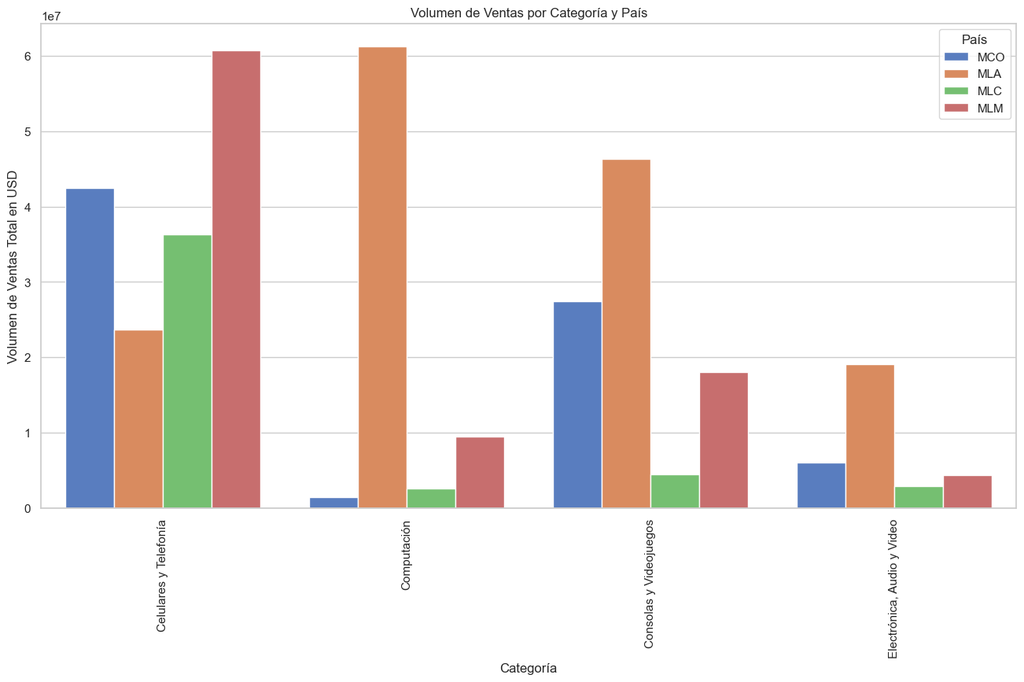

```python
# Configurar gráficos de Seaborn
#sns.set(style="whitegrid")

# Volumen de Ventas por Categoría y País
plt.figure(figsize=(16, 8))
sns.barplot(x='category_name', y='total_sales_volume_usd', hue='site_id', data=category_summary_df, palette='muted')
plt.xlabel('Categoría')
plt.ylabel('Volumen de Ventas Total en USD')
plt.title('Volumen de Ventas por Categoría y País')
plt.xticks(rotation=90)
plt.legend(title='País')
plt.show()
```

Volumen de ventas POTENCIAL

- Vemos que MX lidera con un volumen de ventas potencial en la categoría celulares y telefonía, mientras que en consolas y videojuegos y E,A&V está detrás de Argentina y Colombia

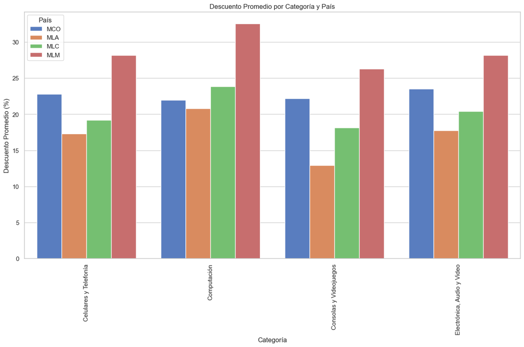

```python
# Descuento Promedio por Categoría y País
plt.figure(figsize=(16, 8))
sns.barplot(x='category_name', y='average_discount_percentage_usd', hue='site_id', data=category_summary_df, palette='muted')
plt.xlabel('Categoría')
plt.ylabel('Descuento Promedio (%)')
plt.title('Descuento Promedio por Categoría y País')
plt.xticks(rotation=90)
plt.legend(title='País')
plt.show()
```

México ofrece % más altos de descuento, por lo que podemos pensar en que MX es sensible a promociones y descuentos. Deberíamos tener esto en mente para estrategias de pricing y descuentos

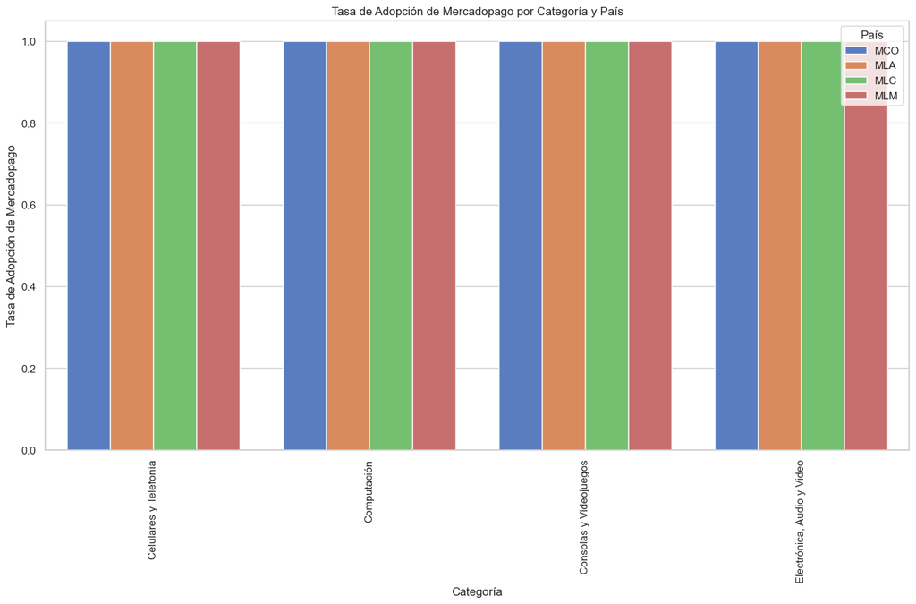

```python
# Tasa de Adopción de Mercadopago por Categoría y País
plt.figure(figsize=(16, 8))
sns.barplot(x='category_name', y='mercadopago_adoption_rate', hue='site_id', data=category_summary_df, palette='muted')
plt.xlabel('Categoría')
plt.ylabel('Tasa de Adopción de Mercadopago')
plt.title('Tasa de Adopción de Mercadopago por Categoría y País')
plt.xticks(rotation=90)
plt.legend(title='País')
plt.show()
```

La tasa de adopción es 100%, lo que me indica que es obligatorio el permitir pagos con mercado pago

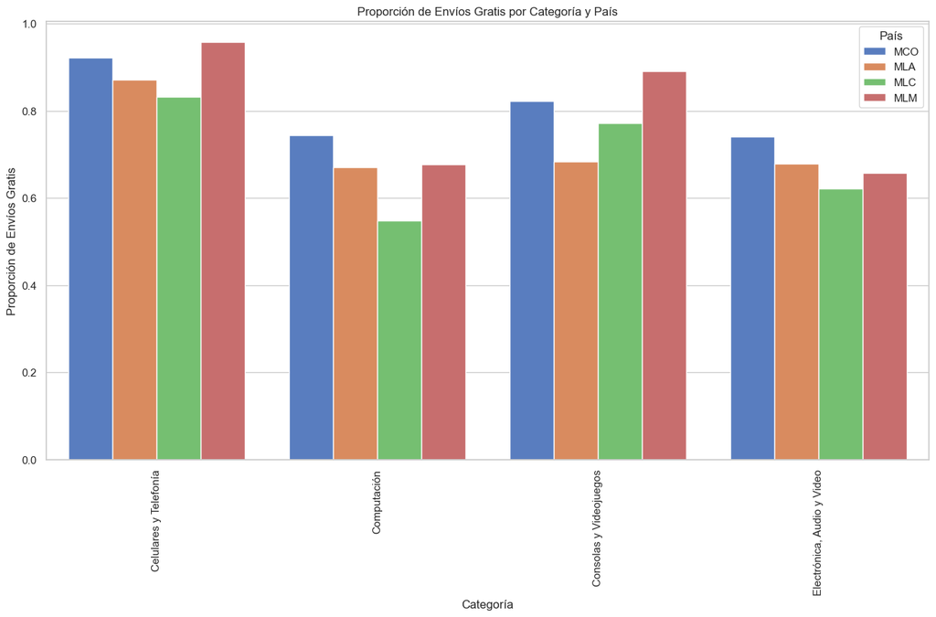

```python
# Proporción de Envíos Gratis por Categoría y País
plt.figure(figsize=(16, 8))
sns.barplot(x='category_name', y='free_shipping_rate', hue='site_id', data=category_summary_df, palette='muted')
plt.xlabel('Categoría')
plt.ylabel('Proporción de Envíos Gratis')
plt.title('Proporción de Envíos Gratis por Categoría y País')
plt.xticks(rotation=90)
plt.legend(title='País')
plt.show()
```

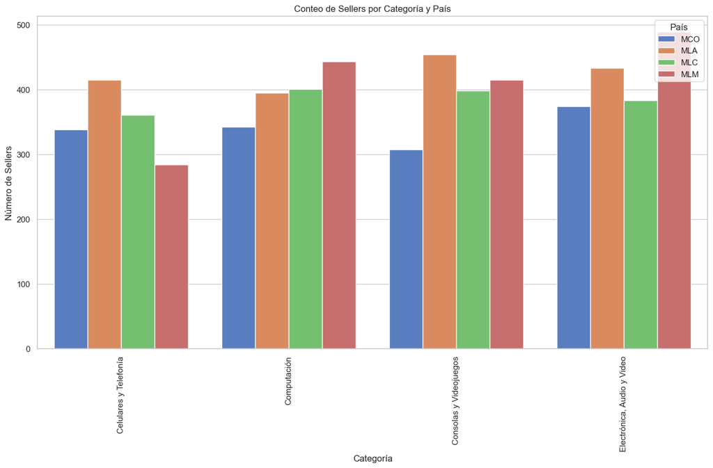

```python
# Conteo de Sellers por Categoría y País
plt.figure(figsize=(16, 8))
sns.barplot(x='category_name', y='sellers_count', hue='site_id', data=category_summary_df, palette='muted')
plt.xlabel('Categoría')
plt.ylabel('Número de Sellers')
plt.title('Conteo de Sellers por Categoría y País')
plt.xticks(rotation=90)
plt.legend(title='País')
plt.show()
```

- A pesar de que el volumen de ventas potencial en MX es mayor para celulares, vemos que es el país con menor cantidad de sellers. Lo que nos puede sugerir que hay una concentración de items en sellers y puede haber una oportunidad de entrada para nuevos sellers

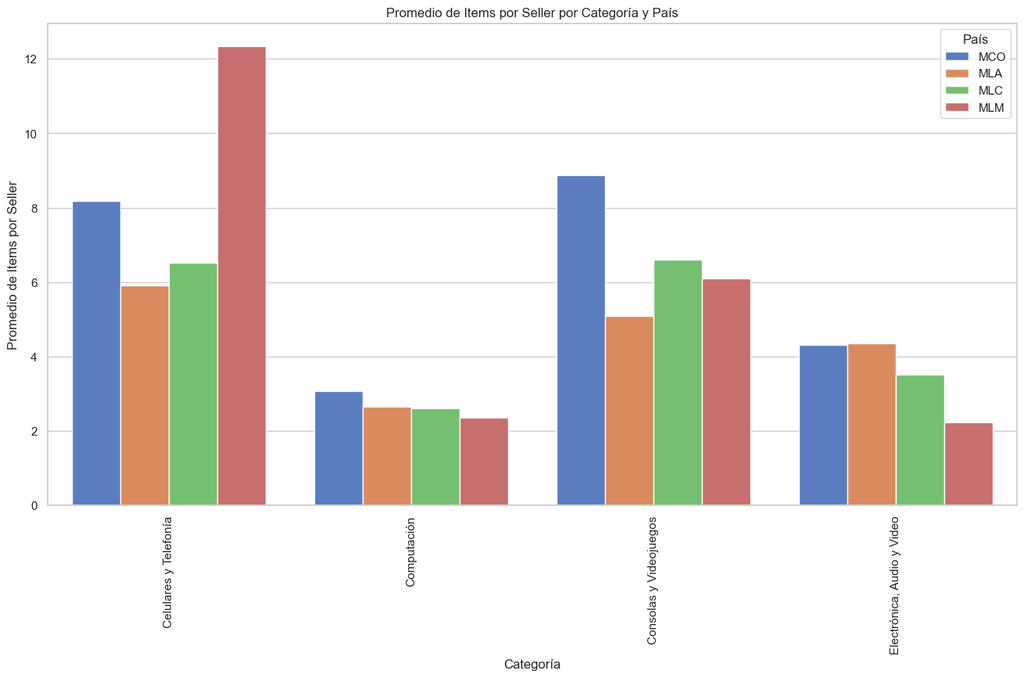

```python
# Promedio de Items por Seller por Categoría y País
plt.figure(figsize=(16, 8))
sns.barplot(x='category_name', y='avg_items_per_seller', hue='site_id', data=category_summary_df, palette='muted')
plt.xlabel('Categoría')
plt.ylabel('Promedio de Items por Seller')
plt.title('Promedio de Items por Seller por Categoría y País')
plt.xticks(rotation=90)
plt.legend(title='País')
plt.show()
```

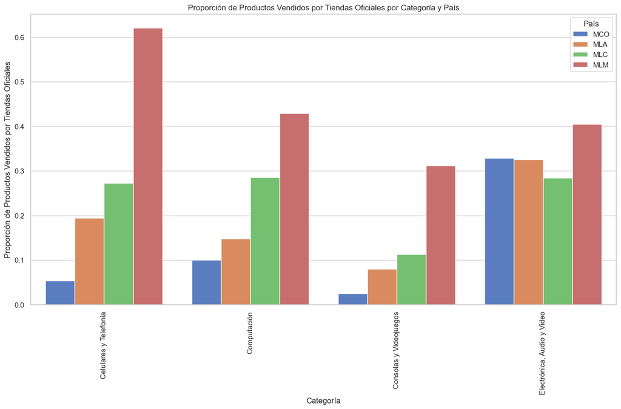

```python
# Crear la gráfica
plt.figure(figsize=(16, 8))
sns.barplot(x='category_name', y='official_store_proportion', hue='site_id', data=category_summary_df, palette='muted')
plt.xlabel('Categoría')
plt.ylabel('Proporción de Productos Vendidos por Tiendas Oficiales')
plt.title('Proporción de Productos Vendidos por Tiendas Oficiales por Categoría y País')
plt.xticks(rotation=90)
plt.legend(title='País')
plt.show()
```

```python
category_summary_df
```

|  | site_id | category_name | total_sales_volume_usd | average_discount_percentage_usd | mercadopago_adoption_rate | free_shipping_rate | items_count | sellers_count | avg_items_per_seller | official_store_items_count | official_store_proportion |
| --- | --- | --- | --- | --- | --- | --- | --- | --- | --- | --- | --- |
| 0 | MCO | Celulares y Telefonía | 42,479,634.55 | 22.78 | 1.00 | 0.92 | 2765 | 338 | 8.18 | 148 | 0.05 |
| 1 | MCO | Computación | 1,485,273.76 | 21.94 | 1.00 | 0.74 | 1046 | 342 | 3.06 | 105 | 0.10 |
| 2 | MCO | Consolas y Videojuegos | 27,425,734.77 | 22.19 | 1.00 | 0.82 | 2789 | 307 | 8.86 | 69 | 0.02 |
| 3 | MCO | Electrónica, Audio y Video | 5,982,542.47 | 23.51 | 1.00 | 0.74 | 1612 | 374 | 4.31 | 531 | 0.33 |
| 4 | MLA | Celulares y Telefonía | 23,716,704.93 | 17.33 | 1.00 | 0.87 | 2453 | 415 | 5.91 | 477 | 0.19 |
| 5 | MLA | Computación | 61,240,678.62 | 20.82 | 1.00 | 0.67 | 1044 | 395 | 2.64 | 154 | 0.15 |
| 6 | MLA | Consolas y Videojuegos | 46,304,951.94 | 12.92 | 1.00 | 0.68 | 2307 | 454 | 5.08 | 184 | 0.08 |
| 7 | MLA | Electrónica, Audio y Video | 19,071,056.69 | 17.74 | 1.00 | 0.68 | 1880 | 433 | 4.34 | 612 | 0.33 |
| 8 | MLC | Celulares y Telefonía | 36,317,731.68 | 19.18 | 1.00 | 0.83 | 2350 | 361 | 6.51 | 640 | 0.27 |
| 9 | MLC | Computación | 2,575,758.07 | 23.86 | 1.00 | 0.55 | 1044 | 401 | 2.60 | 298 | 0.29 |
| 10 | MLC | Consolas y Videojuegos | 4,512,033.90 | 18.13 | 1.00 | 0.77 | 2628 | 398 | 6.60 | 298 | 0.11 |
| 11 | MLC | Electrónica, Audio y Video | 2,929,493.61 | 20.42 | 1.00 | 0.62 | 1342 | 383 | 3.50 | 382 | 0.28 |
| 12 | MLM | Celulares y Telefonía | 60,708,710.57 | 28.18 | 1.00 | 0.96 | 3505 | 284 | 12.34 | 2176 | 0.62 |
| 13 | MLM | Computación | 9,433,506.51 | 32.56 | 1.00 | 0.68 | 1042 | 443 | 2.35 | 448 | 0.43 |
| 14 | MLM | Consolas y Videojuegos | 18,050,929.59 | 26.28 | 1.00 | 0.89 | 2528 | 415 | 6.09 | 788 | 0.31 |
| 15 | MLM | Electrónica, Audio y Video | 4,391,405.35 | 28.18 | 1.00 | 0.66 | 1092 | 489 | 2.23 | 442 | 0.40 |

## 2.2 Análisis por sellers

Ahora, agruparé por seller y calcularé algunas métricas como:

1. media y desviación estándar del precio en USD
2. Volumen potencial de ventas en USD
3. Media de % de descuento
4. adopción de mercado-pago, aunque es irrelevante porque es 100%
5. Proporción de items con envío gratis
6. Moda de categoría: o sea en que categoría tiene más items
7. Cantidad disponible (inventario)
8. Número promedio de installments
9. Tasa promedio de los installments
10. Número total de items
11. Número de items distintos
12. Número de categorías distintas
13. Ratio Media / Desviación del precio

```python
# Agrupar por seller_id y cálculo de key metrics
grouped_sellers = df.groupby(['site_id','seller_id', 'seller_nickname', 'is_official_store']).agg({
    'price_usd': ['mean', 'std'],                # Average and standard deviation of price in USD
    'sales_volume_usd': 'sum',                   # Total sales volume in USD
    'discount_percentage_usd': 'mean',           # Average discount percentage in USD
    'mercadopago_adoption': 'mean',              # MercadoPago adoption rate
    'free_shipping': 'mean',                     # Free shipping rate
    'category_name': lambda x: x.mode().iloc[0], # Most frequent category
    'available_quantity': 'sum',                 # Total available quantity
    'installments_quantity': 'mean',             # Average installment quantity
    'installments_rate': 'mean',                 # Average installment rate
    'id': 'count'                                # Total count of items
}).reset_index()

grouped_sellers.columns = ['site_id','seller_id', 'seller_nickname', 'is_official_store',
                           'price_usd_mean', 'price_usd_std',
                           'sales_volume_usd_sum',
                           'discount_percentage_usd_mean',
                           'mercadopago_adoption_mean',
                           'free_shipping_mean',
                           'category_name_mode',
                           'available_quantity_sum',
                           'installments_quantity_mean',
                           'installments_rate_mean',
                           'item_count']

# Distinct items per seller
distinct_items = df.groupby('seller_id')['id'].nunique().reset_index()
distinct_items.columns = ['seller_id', 'distinct_items']

# Distinct categories per seller
distinct_categories = df.groupby('seller_id')['category_name'].nunique().reset_index()
distinct_categories.columns = ['seller_id', 'distinct_categories']

# Merge distinct_items and distinct_categories into grouped_sellers
grouped_sellers = pd.merge(grouped_sellers, distinct_items, on='seller_id', how='left')
grouped_sellers = pd.merge(grouped_sellers, distinct_categories, on='seller_id', how='left')

# Price mean std ratio
grouped_sellers['price_mean_std_ratio'] = grouped_sellers['price_usd_mean'] / grouped_sellers['price_usd_std']

# Sort by sales volume in descending order
grouped_sellers = grouped_sellers.sort_values(by='sales_volume_usd_sum', ascending=False)

# Top 15 relevant sellers
top_sellers = grouped_sellers.head(15)
top_sellers
```

|  | site_id | seller_id | seller_nickname | is_official_store | price_usd_mean | price_usd_std | sales_volume_usd_sum | discount_percentage_usd_mean | mercadopago_adoption_mean | free_shipping_mean | category_name_mode | available_quantity_sum | installments_quantity_mean | installments_rate_mean | item_count | distinct_items | distinct_categories | price_mean_std_ratio |
| --- | --- | --- | --- | --- | --- | --- | --- | --- | --- | --- | --- | --- | --- | --- | --- | --- | --- | --- |
| 122 | MCO | 73,243,604.00 | GREYBAQUEROLEZCANO | 0 | 875.71 | 942.22 | 58,370,442.66 | NaN | 1.00 | 0.98 | Celulares y Teléfonos | 70571 | 35.56 | 0.00 | 164 | 44 | 3 | 0.93 |
| 1097 | MLA | 31,875,925.00 | ESPACIO ELECTRONICA | 0 | 1,132.14 | 312.14 | 51,912,117.25 | 27.62 | 1.00 | 1.00 | Computación | 37425 | 11.43 | 1.27 | 89 | 89 | 1 | 3.63 |
| 3774 | MLM | 527,927,603.00 | MERCADOLIBRE ELECTRONICA_MX | 1 | 819.08 | 563.00 | 23,765,661.98 | 21.42 | 1.00 | 1.00 | Celulares y Telefonía | 44184 | 18.54 | 6.70 | 437 | 139 | 4 | 1.45 |
| 1989 | MLA | 608,846,165.00 | MERCADOLIBRE ELECTRONICA_AR | 1 | 716.06 | 765.02 | 16,763,705.88 | 12.51 | 1.00 | 1.00 | Celulares y Teléfonos | 44132 | 9.16 | 0.12 | 259 | 94 | 4 | 0.94 |
| 2264 | MLC | 16,522,007.00 | ENVIOGRATIS.CL | 0 | 466.96 | 260.43 | 16,507,189.27 | 30.00 | 1.00 | 0.99 | Celulares y Telefonía | 40873 | 10.42 | 0.00 | 277 | 70 | 2 | 1.79 |
| 1381 | MLA | 125,095,349.00 | DINATECHONLINE | 0 | 1,259.03 | 831.40 | 14,005,356.39 | 13.27 | 1.00 | 0.83 | Celulares y Teléfonos | 7984 | 7.00 | 6.18 | 54 | 18 | 4 | 1.51 |
| 1527 | MLA | 179,274,188.00 | DALECLÍCK | 0 | 1,193.76 | 879.16 | 10,992,277.21 | 17.87 | 1.00 | 0.84 | Consolas y Videojuegos | 13502 | 6.49 | 11.97 | 37 | 19 | 3 | 1.36 |
| 2735 | MLC | 550,063,615.00 | MERCADOLIBRE ELECTRONICA_CL | 1 | 560.61 | 455.28 | 9,996,218.12 | 20.19 | 1.00 | 0.99 | Celulares y Telefonía | 27275 | 8.00 | 0.00 | 571 | 229 | 4 | 1.23 |
| 2556 | MLC | 301,258,112.00 | ADMINISTRADORA ADP | 1 | 310.16 | 185.84 | 7,411,531.45 | 13.39 | 1.00 | 0.98 | Celulares y Telefonía | 27019 | 6.00 | 0.00 | 52 | 19 | 4 | 1.67 |
| 3861 | MLM | 659,831,541.00 | SLANG VG | 1 | 76.41 | 118.13 | 6,835,397.04 | 40.14 | 1.00 | 0.96 | Consolas y Videojuegos | 73625 | 22.23 | 40.61 | 225 | 75 | 1 | 0.65 |
| 3874 | MLM | 676,560,693.00 | POCOOFFICIALGLOBAL-MXF | 1 | 290.46 | 137.78 | 5,791,188.05 | 21.39 | 1.00 | 1.00 | Celulares y Telefonía | 31812 | 20.00 | 15.01 | 48 | 12 | 1 | 2.11 |
| 1785 | MLA | 309,453,406.00 | CAMUS ELECTRONICA.COM.AR | 0 | 1,146.60 | 173.11 | 4,586,385.46 | 9.00 | 1.00 | 1.00 | Celulares y Teléfonos | 4000 | 9.00 | 0.00 | 8 | 2 | 2 | 6.62 |
| 1972 | MLA | 576,310,358.00 | S2GTO | 1 | 1,254.92 | 288.29 | 4,517,712.80 | 7.83 | 1.00 | 1.00 | Consolas y Videojuegos | 3600 | 8.00 | 0.00 | 24 | 6 | 1 | 4.35 |
| 1586 | MLA | 198,175,440.00 | AUDIOSTAF ELECTRONIKO | 0 | 1,801.11 | 980.65 | 4,481,690.38 | 10.00 | 1.00 | 1.00 | Consolas y Videojuegos | 2050 | 3.60 | 6.46 | 5 | 2 | 2 | 1.84 |
| 4270 | MLM | 1,300,096,495.00 | CNCUBOTFACTORYSTORE-MXF | 1 | 181.25 | 76.26 | 4,278,173.32 | 36.42 | 1.00 | 1.00 | Celulares y Telefonía | 24366 | 22.68 | 35.16 | 73 | 19 | 2 | 2.38 |

```python
# DF para el Análisis
grouped_sellers.info()
```

```
<class 'pandas.core.frame.DataFrame'>
Int64Index: 4640 entries, 122 to 231
Data columns (total 18 columns):
 #   Column                        Non-Null Count  Dtype
---  ------                        --------------  -----
 0   site_id                       4640 non-null   object
 1   seller_id                     4640 non-null   float64
 2   seller_nickname               4640 non-null   object
 3   is_official_store             4640 non-null   int64
 4   price_usd_mean                4640 non-null   float64
 5   price_usd_std                 2843 non-null   float64
 6   sales_volume_usd_sum          4640 non-null   float64
 7   discount_percentage_usd_mean  1723 non-null   float64
 8   mercadopago_adoption_mean     4640 non-null   float64
 9   free_shipping_mean            4640 non-null   float64
 10  category_name_mode            4640 non-null   object
 11  available_quantity_sum        4640 non-null   int64
 12  installments_quantity_mean    4403 non-null   float64
 13  installments_rate_mean        4403 non-null   float64
 14  item_count                    4640 non-null   int64
 15  distinct_items                4640 non-null   int64
 16  distinct_categories           4640 non-null   int64
 17  price_mean_std_ratio          2843 non-null   float64
dtypes: float64(10), int64(5), object(3)
memory usage: 688.8+ KB
```

```python
# Busco missing values
missing_values = grouped_sellers.isnull().sum()
percentage_missing = (missing_values / len(grouped_sellers)) * 100

# Create a summary DataFrame
missing_summary = pd.DataFrame({
    'Missing Values': missing_values,
    'Percentage': percentage_missing
})

print("Missing Values Summary:")
print(missing_summary)
```

```
Missing Values Summary:
                              Missing Values  Percentage
site_id                                    0        0.00
seller_id                                  0        0.00
seller_nickname                            0        0.00
is_official_store                          0        0.00
price_usd_mean                             0        0.00
price_usd_std                           1797       38.73
sales_volume_usd_sum                       0        0.00
discount_percentage_usd_mean            2917       62.87
mercadopago_adoption_mean                  0        0.00
free_shipping_mean                         0        0.00
category_name_mode                         0        0.00
available_quantity_sum                     0        0.00
installments_quantity_mean               237        5.11
installments_rate_mean                   237        5.11
item_count                                 0        0.00
distinct_items                             0        0.00
distinct_categories                        0        0.00
price_mean_std_ratio                    1797       38.73
```

```python
# Veo que 1797 items no tienen valores, probablemente porque no tienen desv std porque solo es 1 item

# Filter records where price_usd_std is NaN
missing_std_dev = grouped_sellers[grouped_sellers['price_usd_std'].isna()]

# Check if these sellers have only one item
one_item_sellers = missing_std_dev[missing_std_dev['item_count'] == 1]

# Print the number of such sellers and their details if needed
print(f"Number of sellers with NaN std dev and one item: {len(one_item_sellers)}")
print(one_item_sellers[['seller_id', 'seller_nickname', 'item_count']])
```

```
Number of sellers with NaN std dev and one item: 1797
            seller_id                 seller_nickname  item_count
1062    17,905,314.00            COLLINOTIENDAOFICIAL           1
1774   297,697,151.00               SMARTTECHGROUPSRL           1
1219    66,122,080.00                     MAXDIGITAL-           1
4111 1,165,110,486.00                      F1DESK.NET           1
1047    12,581,198.00                         JAZZ PC           1
...               ...                             ...         ...
2760   584,173,596.00        COMERCIALIZADORA CHANITA           1
3177 1,392,337,122.00  INVERSIONESINVERSIONES20230606           1
1468   158,403,018.00                       BLUESTOR3           1
365    213,973,635.00                      MY HOBBIES           1
231    143,246,380.00                     TIENVIR.COL           1

[1797 rows x 3 columns]
```

```python
# Imputo faltantes de std dev con la media para sellers con 1 item
grouped_sellers['price_usd_std'] = grouped_sellers.apply(
    lambda row: row['price_usd_mean'] if pd.isnull(row['price_usd_std']) else row['price_usd_std'],
    axis=1
)
grouped_sellers['price_mean_std_ratio'].fillna(1, inplace=True)
grouped_sellers['installments_quantity_mean'].fillna(0, inplace=True)
grouped_sellers['installments_rate_mean'].fillna(pd.NA, inplace=True)
grouped_sellers['discount_percentage_usd_mean'].fillna(0, inplace=True)

percentil_90 = grouped_sellers['price_mean_std_ratio'].quantile(0.90)
grouped_sellers['price_mean_std_ratio'].replace([np.inf, -np.inf], 1, inplace=True)
grouped_sellers['price_mean_std_ratio'] = grouped_sellers['price_mean_std_ratio'].apply(lambda x: min(x, percentil_90))
```

```python
missing_values = grouped_sellers.isnull().sum()
percentage_missing = (missing_values / len(grouped_sellers)) * 100

# Create a summary DataFrame
missing_summary = pd.DataFrame({
    'Missing Values': missing_values,
    'Percentage': percentage_missing
})

print("Missing Values Summary:")
print(missing_summary)
```

[output not shown]

```python
grouped_sellers.info()
```

[output not shown]

### Ya tenemos el df para el análisis de sellers

#### 1. Primero, entendamos la distribución de las variables

```python
summary_stats = grouped_sellers.describe()
print(summary_stats)
```

[output not shown]

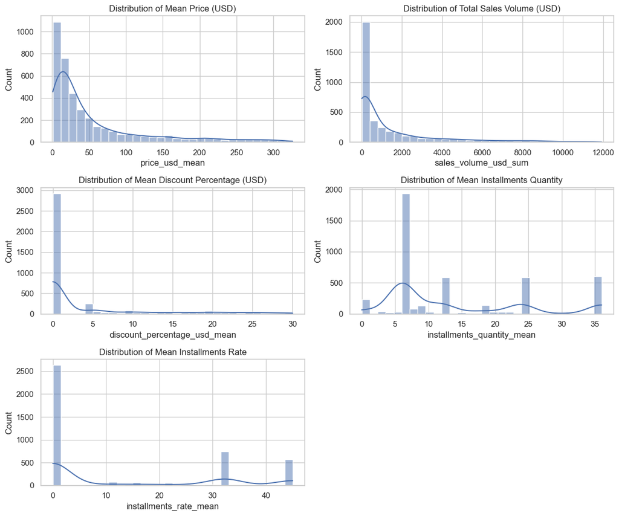

```python
plt.figure(figsize=(12, 10))

plt.subplot(3, 2, 1)
filtered_data = remove_outliers(grouped_sellers, 'price_usd_mean')
sns.histplot(data=filtered_data, x='price_usd_mean', bins=30, kde=True)
plt.title('Distribution of Mean Price (USD)')

plt.subplot(3, 2, 2)
filtered_data = remove_outliers(grouped_sellers, 'sales_volume_usd_sum')
sns.histplot(data=filtered_data, x='sales_volume_usd_sum', bins=30, kde=True)
plt.title('Distribution of Total Sales Volume (USD)')

plt.subplot(3, 2, 3)
filtered_data = remove_outliers(grouped_sellers, 'discount_percentage_usd_mean')
sns.histplot(data=filtered_data, x='discount_percentage_usd_mean', bins=30, kde=True)
plt.title('Distribution of Mean Discount Percentage (USD)')

plt.subplot(3, 2, 4)
filtered_data = remove_outliers(grouped_sellers, 'installments_quantity_mean')
sns.histplot(data=filtered_data, x='installments_quantity_mean', bins=30, kde=True)
plt.title('Distribution of Mean Installments Quantity')

plt.subplot(3, 2, 5)
filtered_data = remove_outliers(grouped_sellers, 'installments_rate_mean')
sns.histplot(data=filtered_data, x='installments_rate_mean', bins=30, kde=True)
plt.title('Distribution of Mean Installments Rate')

plt.tight_layout()
plt.show()
```

### Algunos insigths relevantes al explorar la distribución de variables:

1. Envío gratuito: Alrededor del 62% de los productos ofrecidos por los sellers tienen envío gratuito, lo que puede influir positivamente en las decisiones de compra de los clientes.
2. Diversidad limitada de productos y categorías: Aunque en promedio los sellers tienen 6.76 productos, la mayoría se concentra en una sola categoría (aproximadamente el 75%), indicando una oportunidad para diversificar la oferta y alcanzar nuevos segmentos de mercado.
3. Descuentos promedio: Los sellers ofrecen un descuento promedio del 9.56% en sus productos, lo que sugiere una estrategia común para atraer clientes mediante ofertas especiales.
4. Precio promedio y variabilidad: El precio promedio de los productos es de $154.41 USD, con una variabilidad notable representada por una desviación estándar de 75.57 USD, lo que indica que hay una amplia gama de precios entre los productos ofrecidos.
5. Disponibilidad de productos: La cantidad promedio de productos disponibles es de 501.27 unidades, lo que puede ser crucial para la gestión de inventario y la optimización de la logística.

### Ahora entendamos correlaciones entre variables

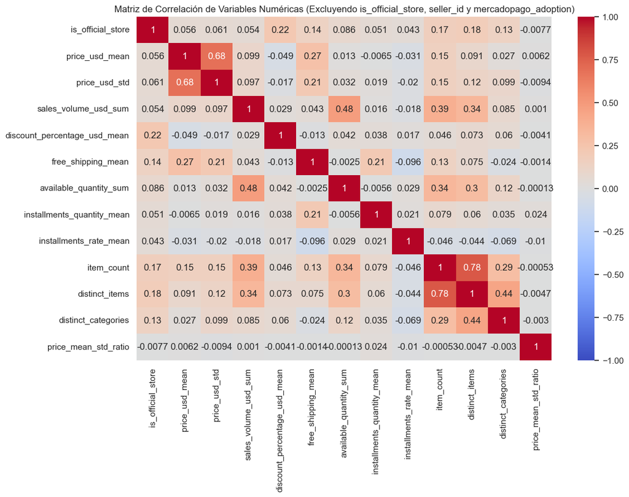

```python
# Seleccionar solo las columnas numéricas excluyendo las mencionadas
numeric_cols = grouped_sellers.select_dtypes(include=['float64', 'int64']).drop(columns=['seller_id', 'mercadopago_adoption_mean'])

correlation_matrix = numeric_cols.corr()
plt.figure(figsize=(12, 8))

sns.heatmap(correlation_matrix, annot=True, cmap='coolwarm', vmin=-1, vmax=1)
plt.title('Matriz de Correlación de Variables Numéricas (Excluyendo is_official_store, seller_id y mercadopago_adoption)')
plt.show()
```

```python
correlation_matrix
```

|  | is_official_store | price_usd_mean | price_usd_std | sales_volume_usd_sum | discount_percentage_usd_mean | free_shipping_mean | available_quantity_sum | installments_quantity_mean | installments_rate_mean | item_count | distinct_items | distinct_categories | price_mean_std_ratio |
| --- | --- | --- | --- | --- | --- | --- | --- | --- | --- | --- | --- | --- | --- |
| is_official_store | 1.00 | 0.06 | 0.06 | 0.05 | 0.22 | 0.14 | 0.09 | 0.05 | 0.04 | 0.17 | 0.18 | 0.13 | -0.01 |
| price_usd_mean | 0.06 | 1.00 | 0.68 | 0.10 | -0.05 | 0.27 | 0.01 | -0.01 | -0.03 | 0.15 | 0.09 | 0.03 | 0.01 |
| price_usd_std | 0.06 | 0.68 | 1.00 | 0.10 | -0.02 | 0.21 | 0.03 | 0.02 | -0.02 | 0.15 | 0.12 | 0.10 | -0.01 |
| sales_volume_usd_sum | 0.05 | 0.10 | 0.10 | 1.00 | 0.03 | 0.04 | 0.48 | 0.02 | -0.02 | 0.39 | 0.34 | 0.08 | 0.00 |
| discount_percentage_usd_mean | 0.22 | -0.05 | -0.02 | 0.03 | 1.00 | -0.01 | 0.04 | 0.04 | 0.02 | 0.05 | 0.07 | 0.06 | -0.00 |
| free_shipping_mean | 0.14 | 0.27 | 0.21 | 0.04 | -0.01 | 1.00 | -0.00 | 0.21 | -0.10 | 0.13 | 0.08 | -0.02 | -0.00 |
| available_quantity_sum | 0.09 | 0.01 | 0.03 | 0.48 | 0.04 | -0.00 | 1.00 | -0.01 | 0.03 | 0.34 | 0.30 | 0.12 | -0.00 |
| installments_quantity_mean | 0.05 | -0.01 | 0.02 | 0.02 | 0.04 | 0.21 | -0.01 | 1.00 | 0.02 | 0.08 | 0.06 | 0.04 | 0.02 |
| installments_rate_mean | 0.04 | -0.03 | -0.02 | -0.02 | 0.02 | -0.10 | 0.03 | 0.02 | 1.00 | -0.05 | -0.04 | -0.07 | -0.01 |
| item_count | 0.17 | 0.15 | 0.15 | 0.39 | 0.05 | 0.13 | 0.34 | 0.08 | -0.05 | 1.00 | 0.78 | 0.29 | -0.00 |
| distinct_items | 0.18 | 0.09 | 0.12 | 0.34 | 0.07 | 0.08 | 0.30 | 0.06 | -0.04 | 0.78 | 1.00 | 0.44 | -0.00 |
| distinct_categories | 0.13 | 0.03 | 0.10 | 0.08 | 0.06 | -0.02 | 0.12 | 0.04 | -0.07 | 0.29 | 0.44 | 1.00 | -0.00 |
| price_mean_std_ratio | -0.01 | 0.01 | -0.01 | 0.00 | -0.00 | -0.00 | -0.00 | 0.02 | -0.01 | -0.00 | -0.00 | -0.00 | 1.00 |

# Análisis de Clustering para encontrar grupos de sellers

```python
grouped_sellers.info()
```

```
<class 'pandas.core.frame.DataFrame'>
Int64Index: 4640 entries, 122 to 231
Data columns (total 18 columns):
 #   Column                        Non-Null Count  Dtype
---  ------                        --------------  -----
 0   site_id                       4640 non-null   object
 1   seller_id                     4640 non-null   float64
 2   seller_nickname               4640 non-null   object
 3   is_official_store             4640 non-null   int64
 4   price_usd_mean                4640 non-null   float64
 5   price_usd_std                 4640 non-null   float64
 6   sales_volume_usd_sum          4640 non-null   float64
 7   discount_percentage_usd_mean  4640 non-null   float64
 8   mercadopago_adoption_mean     4640 non-null   float64
 9   free_shipping_mean            4640 non-null   float64
 10  category_name_mode            4640 non-null   object
 11  available_quantity_sum        4640 non-null   int64
 12  installments_quantity_mean    4640 non-null   float64
 13  installments_rate_mean        4403 non-null   float64
 14  item_count                    4640 non-null   int64
 15  distinct_items                4640 non-null   int64
 16  distinct_categories           4640 non-null   int64
 17  price_mean_std_ratio          4640 non-null   float64
dtypes: float64(10), int64(5), object(3)
memory usage: 688.8+ KB
```

## Variables a considerar

```python
# Seleccionar las variables numéricas y copiar el DataFrame para evitar SettingWithCopyWarning
features = ['is_official_store', 'price_usd_mean', 'price_usd_std', 'sales_volume_usd_sum',
            'discount_percentage_usd_mean', 'free_shipping_mean', 'category_name_mode',
            'installments_quantity_mean', 'installments_rate_mean', 'distinct_items',
            'distinct_categories', 'price_mean_std_ratio']

data = grouped_sellers[features].copy()

data.fillna(data.mean(numeric_only=True), inplace=True)

# Normalizar las variables numéricas
scaler = StandardScaler()
data_scaled = scaler.fit_transform(data.select_dtypes(include=['float64', 'int64']))
```

```python
data['price_mean_std_ratio'].describe()
```

```
count   4,640.00
mean        1.72
std         1.23
min         0.35
25%         1.00
50%         1.00
75%         1.96
max         4.68
Name: price_mean_std_ratio, dtype: float64
```

```python
missing_values = data.isnull().sum()
percentage_missing = (missing_values / len(grouped_sellers)) * 100

missing_summary = pd.DataFrame({
    'Missing Values': missing_values,
    'Percentage': percentage_missing
})

print("Missing Values Summary:")
print(missing_summary)
```

```
Missing Values Summary:
                              Missing Values  Percentage
is_official_store                          0        0.00
price_usd_mean                             0        0.00
price_usd_std                              0        0.00
sales_volume_usd_sum                       0        0.00
discount_percentage_usd_mean               0        0.00
free_shipping_mean                         0        0.00
category_name_mode                         0        0.00
installments_quantity_mean                 0        0.00
installments_rate_mean                     0        0.00
distinct_items                             0        0.00
distinct_categories                        0        0.00
price_mean_std_ratio                       0        0.00
```

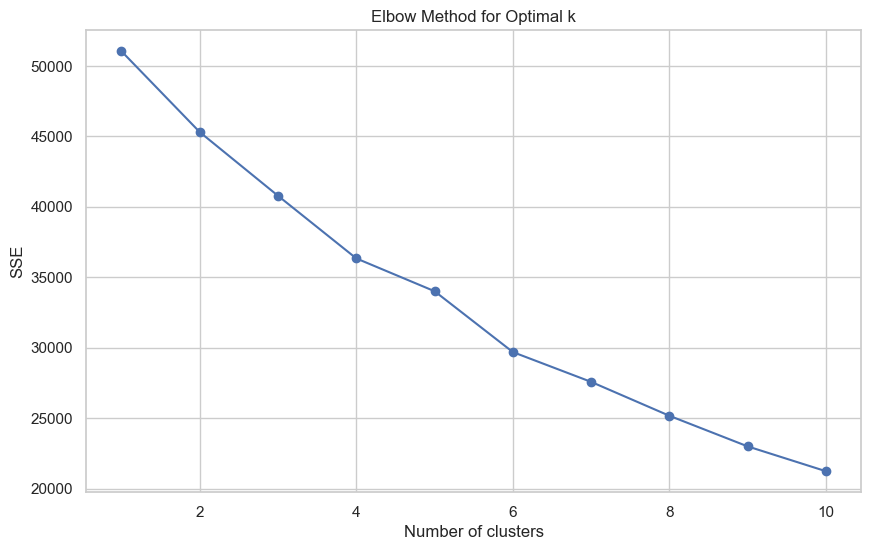

```python
# Paso 1: Método del codo para determinar el número óptimo de clusters
sse = []
for k in range(1, 11):
    kmeans = KMeans(n_clusters=k, random_state=42)
    kmeans.fit(data_scaled)
    sse.append(kmeans.inertia_)

plt.figure(figsize=(10, 6))
plt.plot(range(1, 11), sse, marker='o')
plt.title('Elbow Method for Optimal k')
plt.xlabel('Number of clusters')
plt.ylabel('SSE')
plt.show()
```

```python
optimal_k = 6

# Paso 2: Aplicar K-means
kmeans = KMeans(n_clusters=optimal_k, random_state=42)
clusters = kmeans.fit_predict(data_scaled)
grouped_sellers['Cluster'] = clusters  # Añadir la asignación de clusters al DataFrame original

# Paso 3: Análisis de los clusters
cluster_summary = grouped_sellers.groupby('Cluster').mean()
print(cluster_summary)
```

```
             seller_id  is_official_store  price_usd_mean  price_usd_std  \
Cluster
0       336,934,647.71               0.43          682.62         522.60
1       650,881,564.04               0.00           27.84          10.37
2       595,868,294.08               1.00          180.03          85.85
3       628,047,565.50               0.00          163.48          66.86
4       506,795,385.08               0.12          132.31          98.15
5       353,702,845.53               0.09        1,596.87       1,108.12

         sales_volume_usd_sum  discount_percentage_usd_mean  \
Cluster
0               25,330,940.26                         18.09
1                    5,172.70                          8.81
2                  153,895.54                         18.97
3                   21,320.04                          6.78
4                   97,838.48                         10.19
5                  311,334.62                          5.84

         mercadopago_adoption_mean  free_shipping_mean  \
Cluster
0                             1.00                0.99
1                             1.00                0.05
2                             1.00                0.81
3                             1.00                0.97
4                             1.00                0.58
5                             1.00                0.90

         available_quantity_sum  installments_quantity_mean  \
Cluster
0                     37,780.86                       14.16
1                        444.62                       10.26
2                      1,099.18                       15.89
3                        228.05                       15.90
4                      1,455.10                       15.75
5                        341.04                        9.43

         installments_rate_mean  item_count  distinct_items  \
Cluster
0                          1.16      257.57          127.71
1                         16.16        2.47            1.99
2                         15.74       10.10            5.27
3                         11.55        5.39            2.40
4                          8.62       22.85           14.23
5                         14.44       14.97            5.20

         distinct_categories  price_mean_std_ratio
Cluster
0                       3.14                  1.51
1                       1.18                  1.57
2                       1.39                  1.99
3                       1.14                  1.79
4                       3.28                  1.68
5                       1.50                  1.34
```

```python
cluster_summary_excluding_seller_id = cluster_summary.drop('seller_id', axis=1)

# Mostrar el DataFrame resultante
print(cluster_summary_excluding_seller_id)
```

```
         is_official_store  price_usd_mean  price_usd_std  \
Cluster
0                     0.43          682.62         522.60
1                     0.00           27.84          10.37
2                     1.00          180.03          85.85
3                     0.00          163.48          66.86
4                     0.12          132.31          98.15
5                     0.09        1,596.87       1,108.12

         sales_volume_usd_sum  discount_percentage_usd_mean  \
Cluster
0               25,330,940.26                         18.09
1                    5,172.70                          8.81
2                  153,895.54                         18.97
3                   21,320.04                          6.78
4                   97,838.48                         10.19
5                  311,334.62                          5.84

         mercadopago_adoption_mean  free_shipping_mean  \
Cluster
0                             1.00                0.99
1                             1.00                0.05
2                             1.00                0.81
3                             1.00                0.97
4                             1.00                0.58
5                             1.00                0.90

         available_quantity_sum  installments_quantity_mean  \
Cluster
0                     37,780.86                       14.16
1                        444.62                       10.26
2                      1,099.18                       15.89
3                        228.05                       15.90
4                      1,455.10                       15.75
5                        341.04                        9.43

         installments_rate_mean  item_count  distinct_items  \
Cluster
0                          1.16      257.57          127.71
1                         16.16        2.47            1.99
2                         15.74       10.10            5.27
3                         11.55        5.39            2.40
4                          8.62       22.85           14.23
5                         14.44       14.97            5.20

         distinct_categories  price_mean_std_ratio
Cluster
0                       3.14                  1.51
1                       1.18                  1.57
2                       1.39                  1.99
3                       1.14                  1.79
4                       3.28                  1.68
5                       1.50                  1.34
```

### Cluster Summary

#### Cluster 0: Diversificados Establecidos

- **Precios**: Altos (promedio de 682.62 USD) con una variabilidad considerable (std de $522.60 USD).
- **Ventas**: Volumen de ventas significativo (25,330,940.26 USD).
- **Envío Gratis**: Alta tasa de envío gratis (0.99).
- **Diversidad de Productos**: Alta diversidad de productos (127.71 distintos ítems y 3.14 categorías distintas).

**Conclusión**: Los vendedores en este cluster tienen un amplio catálogo de productos con precios altos y un volumen de ventas significativo. La alta tasa de envío gratis puede ser un factor atractivo para los clientes.

**Accionables**:

- **Explorar nuevas categorías de mercado**: Incentivar la introducción de más líneas de productos de categorías relacionadas.
- **Optimizar y gestionar el inventario**: Implementar estrategias de gestión de inventario para maximizar las ventas.

#### Cluster 1: Iniciadores de Bajo Costo

- **Precios**: Bajos (promedio de 27.84 USD).
- **Ventas**: Bajo volumen de ventas (5,172.70 USD).
- **Envío Gratis**: Baja tasa de envío gratis (0.05).
- **Diversidad de Productos**: Baja (1.99 distintos ítems y 1.18 categorías distintas).

**Conclusión**: Este grupo se caracteriza por precios bajos y un volumen de ventas bajo. La baja tasa de envío gratis y la baja diversidad de productos podrían estar limitando el atractivo de estos vendedores.

**Accionables**:

- **Mejorar la visibilidad**: Aumentar la visibilidad a través de campañas de marketing y ofrecer Ads.
- **Incentivos para aumentar el tamaño del carrito**: Ofrecer productos complementarios para aumentar el valor del carrito.
- **Explorar alianzas con otros vendedores**: Crear paquetes de productos complementarios.

#### Cluster 2: Gigantes Oficiales

- **Precios**: Moderados (promedio de 180.03 USD).
- **Ventas**: Alto volumen de ventas (153,895.54 USD).
- **Envío Gratis**: Alta tasa de envío gratis (0.81).
- **Diversidad de Productos**: Moderada (5.27 distintos ítems y 1.39 categorías distintas).

**Conclusión**: Estos vendedores oficiales tienen un alto volumen de ventas con precios moderados y una oferta de productos diversa.

**Accionables**:

- **Colaboraciones para productos exclusivos**: Trabajar con marcas para ofrecer productos exclusivos.
- **Nuevos mercados geográficos**: Expandir a nuevos mercados geográficos.
- **Marketing omnicanal**: Implementar campañas de marketing tanto online como offline.
- **Programas de lealtad**: Crear programas de lealtad y promociones especiales para retener clientes.

#### Cluster 3: Aspirantes de Nicho

- **Precios**: Moderados (promedio de 163.48 USD).
- **Ventas**: Bajo volumen de ventas (21,320.04 USD).
- **Envío Gratis**: Alta tasa de envío gratis (0.97).
- **Diversidad de Productos**: Baja (2.40 distintos ítems y 1.14 categorías distintas).

**Conclusión**: Estos vendedores tienen precios moderados y una alta tasa de envío gratis, pero su volumen de ventas y la diversidad de productos son bajos.

**Accionables**:

- **Diversificación de productos**: Incentivar la diversificación de productos para captar más clientes.
- **Programas de capacitación**: Proveer programas de capacitación para mejorar la presentación y marketing de productos.

#### Cluster 4: Exploradores Moderados

- **Precios**: Moderados (promedio de 132.31 USD).
- **Ventas**: Volumen de ventas moderado (97,838.48 USD).
- **Envío Gratis**: Tasa de envío gratis moderada (0.58).
- **Diversidad de Productos**: Moderada (14.23 distintos ítems y 3.28 categorías distintas).

**Conclusión**: Este cluster se caracteriza por precios y diversidad de productos moderados, con un volumen de ventas también moderado.

**Accionables**:

- **Capacitaciones y recursos para exploración de mercados**: Proveer capacitaciones y recursos para explorar nuevos mercados.
- **Promociones por tiempo limitado**: Incentivar promociones por tiempo limitado para aumentar las ventas rápidas.

#### Cluster 5: Premium Movers

- **Precios**: Altos (promedio de 1,596.87 USD).
- **Ventas**: Alto volumen de ventas (311,334.62 USD).
- **Envío Gratis**: Alta tasa de envío gratis (0.90).
- **Diversidad de Productos**: Moderada (5.20 distintos ítems y 1.50 categorías distintas).

**Conclusión**: Los vendedores en este cluster ofrecen productos de alto precio con un volumen de ventas alto y una diversidad moderada de productos.

**Accionables**:

- **Estrategias de marketing premium**: Implementar campañas que resalten exclusividad y calidad de sus productos.
- **Explorar mercados internacionales**: Expandir la base de clientes a mercados internacionales.

### Siguientes pasos / Implementación

1. **Validar clusters con insights cualitativos y feedback de usuarios**: Considerar métricas adicionales como funnel y conversión, opiniones, preguntas, tipo de compradores, etc.
2. **Deep Dive por categoría y subcategoría**: Identificar oportunidades específicas para cada segmento.
3. **Experimentación con grupo controlado**: Realizar experimentos controlados, analizar resultados y hacer ajustes antes del despliegue completo.

### Resumen de Clusters

| Cluster | Características Principales | Accionables |
| --- | --- | --- |
| Diversificados Establecidos | - Precios altos - Alta tasa de envío gratis - Volumen de ventas significativo - Alta diversidad de productos | - Explorar nuevas categorías de mercado - Optimizar y gestionar el inventario |
| Iniciadores de Bajo Costo | - Precios bajos - Bajo volumen de ventas - Baja tasa de envío gratis - Baja diversidad de productos | - Mejorar la visibilidad a través de campañas de marketing - Ofrecer Ads - Incentivos de compra |
| Gigantes Oficiales | - Precios moderados - Alto volumen de ventas - Alta tasa de envío gratis - Diversidad moderada de productos | - Colaboraciones para productos exclusivos - Nuevos mercados geográficos - Marketing omnicanal |
| Aspirantes de Nicho | - Precios moderados - Bajo volumen de ventas - Alta tasa de envío gratis - Baja diversidad de productos | - Diversificación de productos - Programas de capacitación |
| Exploradores Moderados | - Precios moderados - Volumen de ventas moderado - Tasa de envío gratis moderada - Diversidad moderada de productos | - Capacitaciones y recursos para exploración de mercados - Promociones por tiempo limitado |
| Premium Movers | - Precios altos - Alto volumen de ventas - Alta tasa de envío gratis - Diversidad moderada de productos | - Estrategias de marketing premium - Explorar mercados internacionales |

```python
# Diccionario de nombres de clusters
cluster_names = {
    0: 'Diversificados Establecidos',
    1: 'Iniciadores de Bajo Costo',
    2: 'Gigantes Oficiales',
    3: 'Aspirantes de Nicho',
    4: 'Exploradores Moderados',
    5: 'Premium Movers'
}

# Asignar nombres a los clusters en el DataFrame
grouped_sellers['cluster_name'] = grouped_sellers['Cluster'].map(cluster_names)

# Mostrar el DataFrame con los nombres de los clusters
print(grouped_sellers[['seller_id', 'Cluster', 'cluster_name']])
```

```
            seller_id  Cluster                 cluster_name
122     73,243,604.00        0  Diversificados Establecidos
1097    31,875,925.00        0  Diversificados Establecidos
3774   527,927,603.00        0  Diversificados Establecidos
1989   608,846,165.00        0  Diversificados Establecidos
2264    16,522,007.00        0  Diversificados Establecidos
...               ...      ...                          ...
2760   584,173,596.00        1    Iniciadores de Bajo Costo
3177 1,392,337,122.00        1    Iniciadores de Bajo Costo
1468   158,403,018.00        1    Iniciadores de Bajo Costo
365    213,973,635.00        1    Iniciadores de Bajo Costo
231    143,246,380.00        1    Iniciadores de Bajo Costo

[4640 rows x 3 columns]
```

```python
representative_sellers = grouped_sellers.groupby(['cluster_name', 'site_id']).apply(lambda x: x.nlargest(2, 'sales_volume_usd_sum')).reset_index(drop=True)

columns_to_display = ['cluster_name', 'site_id', 'seller_nickname', 'sales_volume_usd_sum', 'price_usd_mean', 'price_usd_std', 'category_name_mode']

representative_sellers_display = representative_sellers[columns_to_display]

representative_sellers_display
```

|  | cluster_name | site_id | seller_nickname | sales_volume_usd_sum | price_usd_mean | price_usd_std | category_name_mode |
| --- | --- | --- | --- | --- | --- | --- | --- |
| 0 | Aspirantes de Nicho | MCO | MIRMAMAYACHURY | 955,882.20 | 130.36 | 63.70 | Consolas y Videojuegos |
| 1 | Aspirantes de Nicho | MCO | OVERGAMESPS | 926,373.04 | 222.88 | 62.22 | Consolas y Videojuegos |
| 2 | Aspirantes de Nicho | MLA | CAMUS ELECTRONICA.COM.AR | 4,586,385.46 | 1,146.60 | 173.11 | Celulares y Teléfonos |
| 3 | Aspirantes de Nicho | MLA | VELOCITYARG | 4,046,378.67 | 1,072.57 | 219.73 | Consolas y Videojuegos |
| 4 | Aspirantes de Nicho | MLC | CNMOUNTZION-CLR | 2,312,627.58 | 289.08 | 37.59 | Celulares y Telefonía |
| 5 | Aspirantes de Nicho | MLC | SOSE600876 | 953,046.00 | 47.65 | 0.00 | Consolas y Videojuegos |
| 6 | Aspirantes de Nicho | MLM | ROGAUTHORIZEDRESELLER-MXF | 1,109,354.75 | 761.12 | 202.56 | Celulares y Telefonía |
| 7 | Aspirantes de Nicho | MLM | MUNDOELECTRÓNICOMX1 | 975,436.83 | 474.61 | 270.84 | Celulares y Telefonía |
| 8 | Diversificados Establecidos | MCO | GREYBAQUEROLEZCANO | 58,370,442.66 | 875.71 | 942.22 | Celulares y Teléfonos |
| 9 | Diversificados Establecidos | MLA | ESPACIO ELECTRONICA | 51,912,117.25 | 1,132.14 | 312.14 | Computación |
| 10 | Diversificados Establecidos | MLA | MERCADOLIBRE ELECTRONICA_AR | 16,763,705.88 | 716.06 | 765.02 | Celulares y Teléfonos |
| 11 | Diversificados Establecidos | MLC | ENVIOGRATIS.CL | 16,507,189.27 | 466.96 | 260.43 | Celulares y Telefonía |
| 12 | Diversificados Establecidos | MLC | MERCADOLIBRE ELECTRONICA_CL | 9,996,218.12 | 560.61 | 455.28 | Celulares y Telefonía |
| 13 | Diversificados Establecidos | MLM | MERCADOLIBRE ELECTRONICA_MX | 23,765,661.98 | 819.08 | 563.00 | Celulares y Telefonía |
| 14 | Exploradores Moderados | MCO | TIENDA-OFICIAL-EN-LINEA | 2,615,962.56 | 226.95 | 174.64 | Electrónica, Audio y Video |
| 15 | Exploradores Moderados | MCO | LEORTIZ000 | 1,349,846.65 | 498.37 | 319.13 | Consolas y Videojuegos |
| 16 | Exploradores Moderados | MLA | PCCENTERCOMPUTERS | 1,894,392.65 | 1,321.97 | 427.16 | Computación |
| 17 | Exploradores Moderados | MLA | ELECTRO WORLD2 | 743,695.15 | 192.55 | 223.85 | Celulares y Teléfonos |
| 18 | Exploradores Moderados | MLC | ADMINISTRADORA ADP | 7,411,531.45 | 310.16 | 185.84 | Celulares y Telefonía |
| 19 | Exploradores Moderados | MLC | USER 07 | 503,774.96 | 347.55 | 185.35 | Celulares y Telefonía |
| 20 | Exploradores Moderados | MLM | NUVITU | 3,277,023.73 | 240.44 | 155.86 | Consolas y Videojuegos |
| 21 | Exploradores Moderados | MLM | GRUPODECME | 826,554.86 | 494.55 | 295.77 | Computación |
| 22 | Gigantes Oficiales | MCO | CORBETAOVER | 819,623.78 | 409.81 | 0.00 | Electrónica, Audio y Video |
| 23 | Gigantes Oficiales | MCO | CHALLENGER S.A.S. | 544,540.66 | 222.26 | 92.08 | Electrónica, Audio y Video |
| 24 | Gigantes Oficiales | MLA | S2GTO | 4,517,712.80 | 1,254.92 | 288.29 | Consolas y Videojuegos |
| 25 | Gigantes Oficiales | MLA | COLLINOTIENDAOFICIAL | 3,200,131.19 | 640.03 | 640.03 | Consolas y Videojuegos |
| 26 | Gigantes Oficiales | MLC | TELEFONICATELEFONICA2023011311 | 713,384.44 | 225.18 | 121.81 | Celulares y Telefonía |
| 27 | Gigantes Oficiales | MLC | JUEGOSDEVIDEODECHILESPAJU | 278,204.70 | 65.45 | 73.23 | Electrónica, Audio y Video |
| 28 | Gigantes Oficiales | MLM | SLANG VG | 6,835,397.04 | 76.41 | 118.13 | Consolas y Videojuegos |
| 29 | Gigantes Oficiales | MLM | POCOOFFICIALGLOBAL-MXF | 5,791,188.05 | 290.46 | 137.78 | Celulares y Telefonía |
| 30 | Iniciadores de Bajo Costo | MCO | AYF_ACCESORIOS_COLOMBIA_ | 158,256.97 | 9.26 | 8.38 | Celulares y Teléfonos |
| 31 | Iniciadores de Bajo Costo | MCO | TEAMSAFARI | 96,178.87 | 6.41 | 0.69 | Celulares y Teléfonos |
| 32 | Iniciadores de Bajo Costo | MLA | G-COMMERCE SA | 1,568,550.77 | 12.73 | 4.88 | Computación |
| 33 | Iniciadores de Bajo Costo | MLA | SMART-CLICK | 769,758.22 | 16.78 | 29.10 | Computación |
| 34 | Iniciadores de Bajo Costo | MLC | SEL IMPORT | 103,172.52 | 10.32 | 4.86 | Computación |
| 35 | Iniciadores de Bajo Costo | MLC | LOBOTECH SPA | 64,404.35 | 12.64 | 12.09 | Celulares y Telefonía |
| 36 | Iniciadores de Bajo Costo | MLM | TIENDAOFICIALMKTAN | 44,327.81 | 10.45 | 2.41 | Celulares y Telefonía |
| 37 | Iniciadores de Bajo Costo | MLM | KACOOLMALLMX1 | 40,309.90 | 18.03 | 14.22 | Electrónica, Audio y Video |
| 38 | Premium Movers | MCO | INVERSIONESROJASURBINASAS | 7,471.42 | 1,867.86 | 1,101.46 | Computación |
| 39 | Premium Movers | MCO | WEBSITE APPLEBOGOTA.COM | 5,185.63 | 2,592.82 | 2,183.71 | Computación |
| 40 | Premium Movers | MLA | DINATECHONLINE | 14,005,356.39 | 1,259.03 | 831.40 | Celulares y Teléfonos |
| 41 | Premium Movers | MLA | DALECLÍCK | 10,992,277.21 | 1,193.76 | 879.16 | Consolas y Videojuegos |
| 42 | Premium Movers | MLM | MUSIC.TOP | 37,697.74 | 753.95 | 753.95 | Electrónica, Audio y Video |
| 43 | Premium Movers | MLM | HKTHUNDEROBOT-MXF | 10,399.97 | 721.91 | 970.06 | Computación |

```
Distribución Porcentual de Clusters por País:
cluster_name  Aspirantes de Nicho  Diversificados Establecidos  \
site_id
MCO                         59.35                         0.10
MLA                         44.42                         0.16
MLC                         42.06                         0.29
MLM                         46.26                         0.07

cluster_name  Exploradores Moderados  Gigantes Oficiales  \
site_id
MCO                            10.21                5.72
MLA                             6.13                6.53
MLC                            11.80                5.04
MLM                             3.14               17.41

cluster_name  Iniciadores de Bajo Costo  Premium Movers
site_id
MCO                               23.80            0.82
MLA                               34.91            7.86
MLC                               40.82            0.00
MLM                               32.74            0.37
```

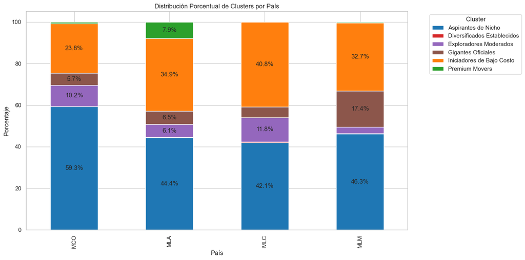

```python
# Asegurando que 'site_id' y 'cluster_name' estén en el DataFrame
if 'site_id' in grouped_sellers.columns and 'cluster_name' in grouped_sellers.columns:
    # Agrupar por 'site_id' (país) y 'Cluster', y contar el número de vendedores en cada grupo
    cluster_country_counts = grouped_sellers.groupby(['site_id', 'cluster_name']).size().unstack(fill_value=0)

    # Convertir conteos a porcentajes del total por país
    cluster_country_percentage = cluster_country_counts.divide(cluster_country_counts.sum(axis=1), axis=0) * 100

    # Mostrar la tabla
    print("Distribución Porcentual de Clusters por País:")
    print(cluster_country_percentage)

    # Definir manualmente la paleta de colores por cluster
    cluster_colors = {
        'Aspirantes de Nicho': 'tab:blue',
        'Iniciadores de Bajo Costo': 'tab:orange',
        'Premium Movers': 'tab:green',
        'Diversificados Establecidos': 'tab:red',
        'Exploradores Moderados': 'tab:purple',
        'Gigantes Oficiales': 'tab:brown'
    }

    # Orden de la leyenda para que coincida con el orden de las barras
    legend_order = cluster_country_percentage.columns.tolist()

    # Crear un gráfico de barras apiladas con una paleta de colores asignada manualmente
    ax = cluster_country_percentage.plot(kind='bar', stacked=True, figsize=(14, 7),
                                         color=[cluster_colors[name] for name in legend_order])
    plt.title('Distribución Porcentual de Clusters por País')
    plt.ylabel('Porcentaje')
    plt.xlabel('País')
    plt.legend([name for name in legend_order], title='Cluster', bbox_to_anchor=(1.05, 1), loc='upper left')
    plt.tight_layout()

    # Añadir etiquetas de porcentaje a cada segmento de las barras apiladas
    for rect in ax.patches:
        height = rect.get_height()
        y = rect.get_y()
        y_text = y + height / 2
        value = round(height, 1)
        if value > 5:
            ax.text(rect.get_x() + rect.get_width() / 2, y_text, f"{value}%", ha='center', va='center')

    # Mostrar el gráfico
    plt.show()
```

```python
clusters_grouped = grouped_sellers.groupby('cluster_name').mean()
```

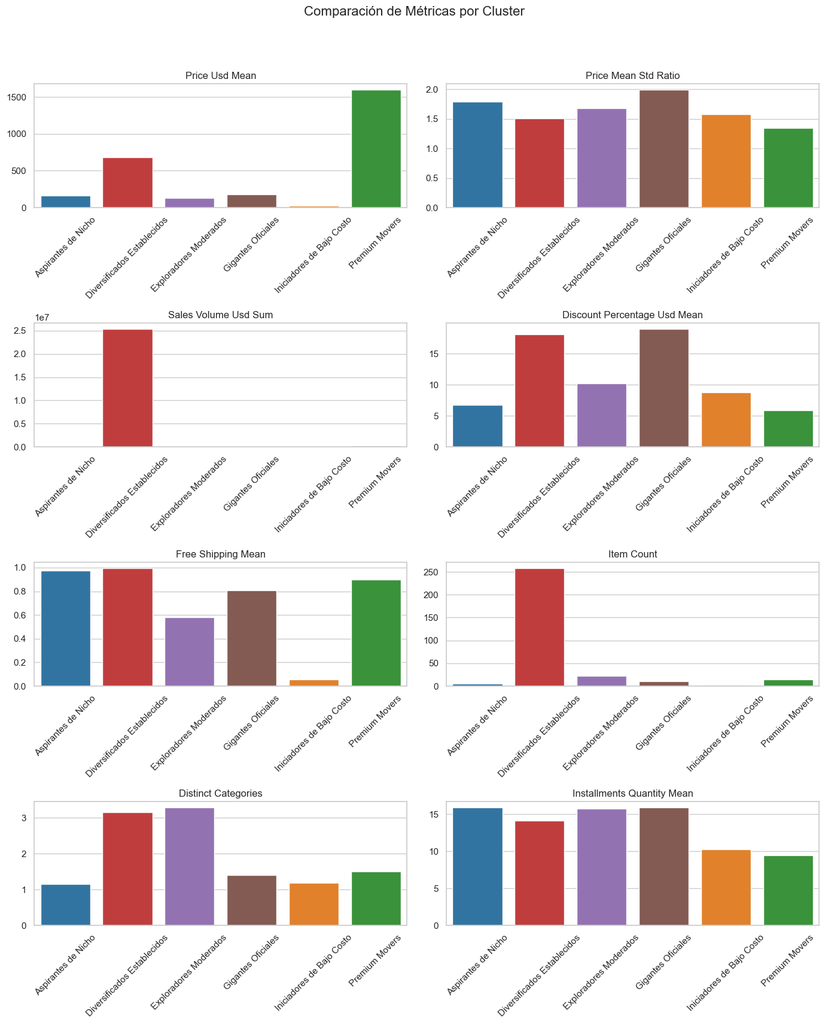

```python
# Configurar el estilo de los gráficos
sns.set(style="whitegrid")

# Lista de métricas para visualizar
metrics = ['price_usd_mean','price_mean_std_ratio', 'sales_volume_usd_sum', 'discount_percentage_usd_mean',
           'free_shipping_mean', 'item_count', 'distinct_categories','installments_quantity_mean']

# Crear una figura y un conjunto de subgráficos
fig, axes = plt.subplots(nrows=4, ncols=2, figsize=(14, 18))
axes = axes.flatten()  # Aplanar la estructura de axes para iterar fácilmente

# Título general
fig.suptitle('Comparación de Métricas por Cluster', fontsize=16)

# Definir manualmente la paleta de colores por cluster
cluster_colors = {
    'Aspirantes de Nicho': 'tab:blue',
    'Iniciadores de Bajo Costo': 'tab:orange',
    'Premium Movers': 'tab:green',
    'Diversificados Establecidos': 'tab:red',
    'Exploradores Moderados': 'tab:purple',
    'Gigantes Oficiales': 'tab:brown'
}

# Crear un gráfico de barras para cada métrica
for i, metric in enumerate(metrics):
    # Asignar colores a cada cluster basado en el diccionario
    color_list = [cluster_colors[cluster_name] for cluster_name in clusters_grouped.index]
    sns.barplot(ax=axes[i], x=clusters_grouped.index, y=clusters_grouped[metric], palette=color_list)
    axes[i].set_title(metric.replace('_', ' ').title())  # Configurar el título del subgráfico
    axes[i].set_ylabel('')  # Limpiar la etiqueta del eje y
    axes[i].set_xlabel('')  # Limpiar la etiqueta del eje x
    axes[i].tick_params(axis='x', labelrotation=45)  # Rotar etiquetas del eje x para mejor legibilidad

# Ajustar el layout para evitar superposiciones
plt.tight_layout(rect=[0, 0.03, 1, 0.95])

# Mostrar el gráfico
plt.show()
```

```python
# Categorías y subcategorías
```

```python
seller_clusters = grouped_sellers[['seller_id', 'cluster_name']]
df_merged = pd.merge(df, seller_clusters, on='seller_id', how='left')
```

```python
df_merged.head()
```

|  | id | title | condition | thumbnail_id | catalog_product_id | listing_type_id | permalink | buying_mode | site_id | category_id | ... | original_price_usd | category_name | sales_volume_usd | discount_percentage_usd | mercadopago_adoption | free_shipping | subcat_id | subcat_name | is_official_store | cluster_name |
| --- | --- | --- | --- | --- | --- | --- | --- | --- | --- | --- | --- | --- | --- | --- | --- | --- | --- | --- | --- | --- | --- |
| 0 | MLM3166352008 | Bocina Jbl Go 3 Jblgo3 Portátil Con Bluetooth ... | new | 624129-MLU72571585392_112023 | MLM16247314 | gold_special | https://www.mercadolibre.com.mx/bocina-jbl-go-... | buy_it_now | MLM | MLM59800 | ... | NaN | Electrónica, Audio y Video | 29.64 | NaN | 1 | 1 | NaN | NaN | 0 | Aspirantes de Nicho |
| 1 | MLM2080126365 | Audífono In-ear Inalámbrico Keluona M90 Pro M9... | new | 909186-MLA71521920131_092023 | MLM26810871 | gold_special | https://www.mercadolibre.com.mx/audifono-in-ea... | buy_it_now | MLM | MLM7533 | ... | 4.21 | Electrónica, Audio y Video | 391.63 | 7.01 | 1 | 0 | NaN | NaN | 0 | Iniciadores de Bajo Costo |
| 2 | MLM2606504262 | Bocina Bluetooth Speaker 1hora Boc241 Para Pc ... | new | 797961-MLA74807969159_022024 | MLM22801217 | gold_special | https://www.mercadolibre.com.mx/bocina-bluetoo... | buy_it_now | MLM | MLM2868 | ... | NaN | Electrónica, Audio y Video | 8,401.44 | NaN | 1 | 1 | NaN | NaN | 0 | Aspirantes de Nicho |
| 3 | MLM1799809870 | Bocina Portátil Jbl Flip 6 Bluetooth Aprueba D... | new | 913774-MLU76917425907_062024 | MLM18930466 | gold_special | https://www.mercadolibre.com.mx/bocina-portati... | buy_it_now | MLM | MLM59800 | ... | NaN | Electrónica, Audio y Video | 85.37 | NaN | 1 | 1 | NaN | NaN | 1 | Gigantes Oficiales |
| 4 | MLM1978928449 | Drone Lyzrc L900 Pro L900 Pro Se L900 Se Con ... | new | 813204-MLA71822760790_092023 | MLM27215338 | gold_pro | https://www.mercadolibre.com.mx/drone-lyzrc-l9... | buy_it_now | MLM | MLM149102 | ... | 250.27 | Electrónica, Audio y Video | 28,153.40 | 55.00 | 1 | 1 | NaN | NaN | 0 | Aspirantes de Nicho |

5 rows × 49 columns

```python
df_merged.info()
```

```
<class 'pandas.core.frame.DataFrame'>
Int64Index: 32912 entries, 0 to 32911
Data columns (total 49 columns):
 #   Column                   Non-Null Count  Dtype
---  ------                   --------------  -----
 0   id                       32912 non-null  object
 1   title                    32912 non-null  object
 2   condition                32912 non-null  object
 3   thumbnail_id             32912 non-null  object
 4   catalog_product_id       27542 non-null  object
 5   listing_type_id          32912 non-null  object
 6   permalink                32912 non-null  object
 7   buying_mode              32912 non-null  object
 8   site_id                  32912 non-null  object
 9   category_id              32912 non-null  object
```

[output cut: 41 more lines]

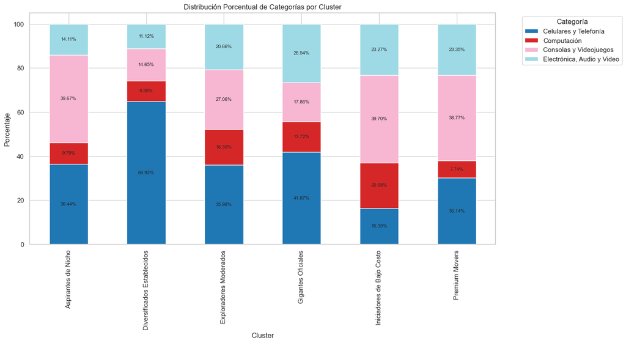

```python
# Estandarizar la etiqueta de la categoría "Celulares y Telefonía"
df_merged['category_name'] = df_merged['category_name'].replace({
    'Celulares y Teléfonos': 'Celulares y Telefonía'
})

# Agrupar por cluster y categoría y contar las entradas
category_distribution = df_merged.groupby(['cluster_name', 'category_name']).size().reset_index(name='count')

# Normalizar el conteo dentro de cada cluster para obtener porcentajes
category_distribution['percentage'] = category_distribution.groupby('cluster_name')['count'].transform(lambda x: x / x.sum() * 100)

# Pivotear los datos para tener categorías en las filas y clusters en las columnas
pivot_data = category_distribution.pivot(index='cluster_name', columns='category_name', values='percentage').fillna(0)

# Crear un gráfico de barras apiladas
fig, ax = plt.subplots(figsize=(14, 7))
pivot_data.plot(kind='bar', stacked=True, colormap='tab20', ax=ax)
plt.title('Distribución Porcentual de Categorías por Cluster')
plt.ylabel('Porcentaje')
plt.xlabel('Cluster')
plt.legend(title='Categoría', bbox_to_anchor=(1.05, 1), loc='upper left')

# Añadir etiquetas de porcentaje en cada segmento de la barra
for rect in ax.patches:
    # Obtener la altura y posición de cada rectángulo
    height = rect.get_height()
    y = rect.get_y()
    if height > 0:  # Solo agregar etiquetas a valores no nulos
        label_text = f'{height:.2f}%'
        label_x = rect.get_x() + rect.get_width() / 2
        label_y = y + height / 2
        ax.text(label_x, label_y, label_text, ha='center', va='center', fontsize=8)

plt.show()
```

```python
# Mostrar la tabla de distribución porcentual
print("Tabla de Distribución Porcentual de Categorías por Cluster:")
print(pivot_data)
```

```
Tabla de Distribución Porcentual de Categorías por Cluster:
category_name                Celulares y Telefonía  Computación  \
cluster_name
Aspirantes de Nicho                          36.44         9.79
Diversificados Establecidos                  64.92         9.30
Exploradores Moderados                       35.98        16.30
Gigantes Oficiales                           41.87        13.72
Iniciadores de Bajo Costo                    16.35        20.68
Premium Movers                               30.14         7.74

category_name                Consolas y Videojuegos  \
cluster_name
Aspirantes de Nicho                           39.67
Diversificados Establecidos                   14.65
Exploradores Moderados                        27.06
Gigantes Oficiales                            17.86
Iniciadores de Bajo Costo                     39.70
Premium Movers                                38.77

category_name                Electrónica, Audio y Video
cluster_name
Aspirantes de Nicho                               14.11
Diversificados Establecidos                       11.12
Exploradores Moderados                            20.66
Gigantes Oficiales                                26.54
Iniciadores de Bajo Costo                         23.27
Premium Movers                                    23.35
```

```python
# Filtrar para obtener los 10 items con mayor volumen de ventas dentro de cada cluster
representative_items = df_merged.groupby('cluster_name').apply(lambda x: x.nlargest(5, 'sales_volume_usd')).reset_index(drop=True)

columns_to_display = ['cluster_name', 'title', 'category_name', 'price_usd', 'sales_volume_usd', 'seller_nickname', 'site_id']

representative_items_display = representative_items[columns_to_display]

representative_items_display.head(20)
```

|  | cluster_name | title | category_name | price_usd | sales_volume_usd | seller_nickname | site_id |
| --- | --- | --- | --- | --- | --- | --- | --- |
| 0 | Aspirantes de Nicho | Electrificador Boyero Seguridad Garantia De Po... | Electrónica, Audio y Video | 35.01 | 1,750,489.30 | HAWX | MLA |
| 1 | Aspirantes de Nicho | Casa Seguridad Perimetral Boyero Electrico E5 | Electrónica, Audio y Video | 35.01 | 1,750,489.30 | HAWX | MLA |
| 2 | Aspirantes de Nicho | Celular Samsung Galaxy Z Flip3 5g 128gb + 8gb ... | Celulares y Telefonía | 1,308.52 | 654,260.79 | CAMUS ELECTRONICA.COM.AR | MLA |
| 3 | Aspirantes de Nicho | Celular Samsung Galaxy Z Flip3 5g 128gb + 8gb ... | Celulares y Telefonía | 1,308.52 | 654,260.79 | CAMUS ELECTRONICA.COM.AR | MLA |
| 4 | Aspirantes de Nicho | Celular Samsung Galaxy Z Flip3 5g 128gb + 8gb ... | Celulares y Telefonía | 1,308.52 | 654,260.79 | CAMUS ELECTRONICA.COM.AR | MLA |
| 5 | Diversificados Establecidos | Notebook Lenovo Ideapad 15alc7 Azul Amd Ryzen ... | Computación | 1,763.89 | 8,819,454.02 | ESPACIO ELECTRONICA | MLA |
| 6 | Diversificados Establecidos | Notebook Lenovo Ideapad 15alc7 Gris Amd Ryzen ... | Computación | 1,625.49 | 8,127,442.09 | ESPACIO ELECTRONICA | MLA |
| 7 | Diversificados Establecidos | Notebook Lenovo Ideapad 15alc7 Abyss Blue Amd ... | Computación | 1,569.80 | 7,848,996.19 | ESPACIO ELECTRONICA | MLA |
| 8 | Diversificados Establecidos | Notebook Lenovo Ideapad Ryzen 7 16gb Ssd 512gb... | Computación | 1,430.41 | 7,152,060.86 | ESPACIO ELECTRONICA | MLA |
| 9 | Diversificados Establecidos | Notebook Hp 15-ef2514la Plata 15.6 , Amd Ryzen... | Computación | 1,394.96 | 6,974,818.28 | ESPACIO ELECTRONICA | MLA |
| 10 | Exploradores Moderados | Celular Xiaomi Redmi Note 13 Eu 8gb Ram 256gb Rom | Celulares y Telefonía | 285.90 | 1,429,516.05 | ADMINISTRADORA ADP | MLC |
| 11 | Exploradores Moderados | Celular Xiaomi Redmi Note 13 Eu 8gb Ram 256gb Rom | Celulares y Telefonía | 285.90 | 1,429,516.05 | ADMINISTRADORA ADP | MLC |
| 12 | Exploradores Moderados | Celular Xiaomi Redmi Note 13 Eu 8gb Ram 256gb Rom | Celulares y Telefonía | 285.90 | 1,429,516.05 | ADMINISTRADORA ADP | MLC |
| 13 | Exploradores Moderados | Celular Xiaomi Redmi Note 13 Eu 8gb Ram 256gb Rom | Celulares y Telefonía | 285.90 | 1,429,516.05 | ADMINISTRADORA ADP | MLC |
| 14 | Exploradores Moderados | Apple iPhone 15 Pro Max (512 Gb) - Titanio Bla... | Celulares y Telefonía | 1,821.62 | 455,404.42 | MERCADOLIBRE ELECTRONICA_MX | MLM |
| 15 | Gigantes Oficiales | Simulador Formula Sim Light Azul Fsim Volante ... | Consolas y Videojuegos | 640.03 | 3,200,131.19 | COLLINOTIENDAOFICIAL | MLA |
| 16 | Gigantes Oficiales | Laptop Lenovo V14 G3 Iap: Intel Core I3 1215u,... | Computación | 295.22 | 1,476,098.14 | TIENDA PCEL | MLM |
| 17 | Gigantes Oficiales | Celular Xiaomi Pocophone Poco C65 Dual Sim 6.7... | Celulares y Telefonía | 135.46 | 677,311.26 | POCOOFFICIALGLOBAL-MXF | MLM |
| 18 | Gigantes Oficiales | Celular Xiaomi Pocophone Poco C65 Dual Sim 6.7... | Celulares y Telefonía | 135.46 | 677,311.26 | POCOOFFICIALGLOBAL-MXF | MLM |
| 19 | Gigantes Oficiales | Celular Xiaomi Pocophone Poco C65 Dual Sim 6.7... | Celulares y Telefonía | 135.46 | 677,311.26 | POCOOFFICIALGLOBAL-MXF | MLM |

### Respuesta a la pregunta del equipo comercial:

Para ayudar al equipo comercial a identificar y clasificar a los sellers con buen perfil y relevancia para el negocio, hemos desarrollado un modelo de clustering que segmenta a los sellers en seis clusters distintos basados en métricas clave como precio, volumen de ventas, envío gratuito, y diversidad de productos. Esta clasificación permite diseñar estrategias focalizadas para cada grupo, optimizando los esfuerzos de marketing y mejorando la relevancia y eficacia de las acciones comerciales. Con esta segmentación, el equipo comercial puede identificar rápidamente los sellers con mayor potencial y adaptar sus estrategias para maximizar el impacto en cada segmento del mercado.